# Trabajo de Estadística

Proyecto r María Arribas

El csv elegido para el proyecto contiene las siguientes variables:

Gender: El género de la persona registrada en el conjunto de datos.

Age: La edad de la persona registrada en el conjunto de datos.

Hypertension: Si la persona registrada en el conjunto de datos tiene hipertensión o no. Hipertensión es una condición médica en la cual la presión arterial de una persona es crónicamente alta.

Heart_disease: Si la persona registrada en el conjunto de datos tiene una enfermedad cardíaca o no.

Smoking_history: Si la persona registrada en el conjunto de datos tiene un historial de fumar o no.

Bmi: El índice de masa corporal (IMC) de la persona registrada en el conjunto de datos. El IMC es una medida de la grasa corporal basada en la altura y el peso de una persona.

HbA1c_level: Nivel de HbA1c en sangre de la persona registrada en el conjunto de datos. HbA1c es una medida del nivel promedio de glucosa en la sangre durante los últimos 2-3 meses. Normal: HbA1c por debajo de 5,7% Prediabetes: HbA1c entre 5,7% y 6,4% Diabetes: HbA1c de 6.5% o más alto.

Blood_glucose_level: El nivel de glucosa en sangre de la persona registrada en el conjunto de datos.

Diabetes: Si la persona registrada en el conjunto de datos tiene diabetes o no. La diabetes es una afección en la que el nivel de azúcar en la sangre de una persona es demasiado alto debido a que su cuerpo no produce o utiliza adecuadamente la insulina.

Fichero csv inicial ajustando los datos al ancho de la pantalla

```r
# Leer el archivo CSV en un DataFrame
dataframe <- read.csv("diabetes_prediction_dataset.csv", header = TRUE)

# Ajustar la opción de ancho de pantalla para mostrar todas las columnas
options(width = 200)

# Imprimir los primero 5 registros
head(dataframe)
```

```
##   gender age hypertension heart_disease smoking_history   bmi HbA1c_level blood_glucose_level diabetes
## 1 Female  80            0             1           never 25.19         6.6                 140        0
## 2 Female  54            0             0         No Info 27.32         6.6                  80        0
## 3   Male  28            0             0           never 27.32         5.7                 158        0
## 4 Female  36            0             0         current 23.45         5.0                 155        0
## 5   Male  76            1             1         current 20.14         4.8                 155        0
## 6 Female  20            0             0           never 27.32         6.6                  85        0
```

Fichero csv sin las filas que no contienen informacion sobre el historial fumador del paciente

```r
# Cargar el archivo CSV
datos <- read.csv("diabetes_prediction_dataset.csv")

# Crear una variable que indique si alguna columna contiene "No Info"
no_info <- apply(datos, 1, function(x) any(grepl("No Info", x)))

# Seleccionar sólo las filas que no contengan "No Info"
datos_limpio <- subset(datos, !no_info)

# Guardar el archivo CSV limpio
write.csv(datos_limpio, file = "datos_limpio.csv", row.names = FALSE)

# Imprimir los primero 5 registros
head(datos_limpio)
```

```
##   gender age hypertension heart_disease smoking_history   bmi HbA1c_level blood_glucose_level diabetes
## 1 Female  80            0             1           never 25.19         6.6                 140        0
## 3   Male  28            0             0           never 27.32         5.7                 158        0
## 4 Female  36            0             0         current 23.45         5.0                 155        0
## 5   Male  76            1             1         current 20.14         4.8                 155        0
## 6 Female  20            0             0           never 27.32         6.6                  85        0
## 7 Female  44            0             0           never 19.31         6.5                 200        1
```

Fichero csv con 500 datos

```r
# Cargar el archivo CSV completo como un data frame
datos_completos <- read.csv("datos_limpio.csv")

# Seleccionar las primeras 500 filas del data frame
datos_reducidos <- head(datos_completos, 500)

# Escribir el data frame resultante a un nuevo archivo CSV
write.csv(datos_reducidos, "nuevo_archivo.csv", row.names = FALSE)

# Imprimir el csv resultante
head(datos_reducidos)
```

```
##   gender age hypertension heart_disease smoking_history   bmi HbA1c_level blood_glucose_level diabetes
## 1 Female  80            0             1           never 25.19         6.6                 140        0
## 2   Male  28            0             0           never 27.32         5.7                 158        0
## 3 Female  36            0             0         current 23.45         5.0                 155        0
## 4   Male  76            1             1         current 20.14         4.8                 155        0
## 5 Female  20            0             0           never 27.32         6.6                  85        0
## 6 Female  44            0             0           never 19.31         6.5                 200        1
```

Generar nuevas columnas a partir de la aplicación de fórmulas a las columnas existentes (tanto numéricas, como cadena y booleanas)

```r
# Cargar el archivo CSV como un data frame
datos <- read.csv("nuevo_archivo.csv")

# Crear una nueva columna "edad_en_meses"
datos$edad_en_meses <- datos$age * 12

# Crear una nueva columna "riesgo_cardiovascular" basada en la presencia de hipertensión o enfermedad cardíaca
datos$riesgo_cardiovascular <- ifelse(datos$hypertension == 1 | datos$heart_disease == 1, "alto", "bajo")

# Crear una nueva columna "fumador" con valores booleanos indicando si la persona fuma o no
datos$fumador <- ifelse(datos$smoking_history != "never", TRUE, FALSE)

# Crear una nueva columna "estado_diabetes" basada en los niveles de HbA1c y glucosa en sangre
datos$estado_diabetes <- ifelse(datos$diabetes == 1, "diabético",
                                 ifelse(datos$HbA1c_level >= 5.7 | datos$blood_glucose_level >= 126, "prediabético", "no diabético"))

#ajustar el ancho de pantalla para mostrar todas las columnas
options(width = 200)

# Escribir los datos actualizados a un nuevo archivo CSV
write.csv(datos, "new_columns.csv", row.names = FALSE)

# Imprimir los primeros 5 registros
head(datos)
```

```
##   gender age hypertension heart_disease smoking_history   bmi HbA1c_level blood_glucose_level diabetes edad_en_meses riesgo_cardiovascular fumador estado_diabetes
## 1 Female  80            0             1           never 25.19         6.6                 140        0           960                  alto   FALSE    prediabético
## 2   Male  28            0             0           never 27.32         5.7                 158        0           336                  bajo   FALSE    prediabético
## 3 Female  36            0             0         current 23.45         5.0                 155        0           432                  bajo    TRUE    prediabético
## 4   Male  76            1             1         current 20.14         4.8                 155        0           912                  alto    TRUE    prediabético
## 5 Female  20            0             0           never 27.32         6.6                  85        0           240                  bajo   FALSE    prediabético
## 6 Female  44            0             0           never 19.31         6.5                 200        1           528                  bajo   FALSE       diabético
```

Generar nuevas columnas a partir de la recodificación de otras.

```r
library(dplyr)
```

```r
# Cargar el archivo CSV como un data frame
datos <- read.csv("new_columns.csv")

# Generar nuevas columnas a partir de la recodificación de otras
datos <- datos %>%
  mutate(new_hypertension = ifelse(hypertension == 1, "Sí", "No"),
         new_heart_disease = ifelse(heart_disease == 1, "Sí", "No"),
         new_smoking_history = ifelse(smoking_history == "never", "Nunca", "Sí"),
         new_bmi = bmi * 2.20462, # conversión de kg/m^2 a lb/pulg^2
         new_diabetes = ifelse(diabetes == 1 & HbA1c_level >= 6.5 | blood_glucose_level >= 200, "Sí", "No"))

#ajustar el ancho de pantalla para mostrar todas las columnas
options(width = 100)

# Imprimir el data frame con las nuevas columnas
head(datos)
```

```
##   gender age hypertension heart_disease smoking_history   bmi HbA1c_level blood_glucose_level
## 1 Female  80            0             1           never 25.19         6.6                 140
## 2   Male  28            0             0           never 27.32         5.7                 158
## 3 Female  36            0             0         current 23.45         5.0                 155
## 4   Male  76            1             1         current 20.14         4.8                 155
## 5 Female  20            0             0           never 27.32         6.6                  85
## 6 Female  44            0             0           never 19.31         6.5                 200
##   diabetes edad_en_meses riesgo_cardiovascular fumador estado_diabetes new_hypertension
## 1        0           960                  alto   FALSE    prediabético               No
## 2        0           336                  bajo   FALSE    prediabético               No
## 3        0           432                  bajo    TRUE    prediabético               No
## 4        0           912                  alto    TRUE    prediabético               Sí
## 5        0           240                  bajo   FALSE    prediabético               No
## 6        1           528                  bajo   FALSE       diabético               No
##   new_heart_disease new_smoking_history  new_bmi new_diabetes
## 1                Sí               Nunca 55.53438           No
## 2                No               Nunca 60.23022           No
## 3                No                  Sí 51.69834           No
## 4                Sí                  Sí 44.40105           No
## 5                No               Nunca 60.23022           No
## 6                No               Nunca 42.57121           Sí
```

La primera columna se llama new_hypertension. Esta fórmula recodifica la variable hypertension, que toma valores 0 o 1, en una variable binaria que indica si el paciente tiene hipertensión (valor 1) o no (valor 0).

La segunda columna se llama new_heart_disease. Esta fórmula recodifica la variable heart_disease, que toma valores 0 o 1, en una variable binaria que indica si el paciente tiene enfermedad cardíaca (valor 1) o no (valor 0).

La quinta columna se llama new_diabetes. Esta fórmula recodifica la variable diabetes. Si el paciente tiene diabetes (valor 1) y su nivel de HbA1c es mayor o igual a 6.5 o su nivel de glucosa en sangre es mayor o igual a 200, entonces la nueva variable toma el valor “Sí”. En caso contrario, toma el valor “No”.

Calcular tablas de frecuencias simples según una o varias variables cualitativas.

### Tabla de frecuencias en funcion del genero

```r
# Cargar datos
data <- read.csv("new_columns.csv")

# Frecuencias absolutas.
ni <- table(data$gender)
# Frecuencias relativas
fi <- prop.table(ni)
# Frecuencias acumuladas.
Ni <- cumsum(ni)
# Frecuencias relativas acumuladas.
Fi <- cumsum(fi)
# Creación de un data frame con las frecuencias.
tabla_frec <- cbind(ni, fi, Ni, Fi)
print(tabla_frec)
```

```
##         ni    fi  Ni    Fi
## Female 311 0.622 311 0.622
## Male   189 0.378 500 1.000
```

### Tabla de frecuencias en funcion del historial de fumador del paciente

```r
# Cargar datos
df <- read.csv("new_columns.csv")

# Seleccionar columna de interés
fuma <- df$smoking_history

# Contar frecuencias
ni <- table(fuma)

# Calcular frecuencias relativas
fi <- prop.table(ni)

# Calcular frecuencias acumuladas
Ni <- cumsum(ni)

# Calcular frecuencias relativas acumuladas
Fi <- cumsum(fi)

# Crear data frame con las frecuencias
tabla_frec <- data.frame(ni = ni, fi = fi, Ni = Ni, Fi = Fi)

tabla_frec
```

```
##                 ni.fuma ni.Freq     fi.fuma fi.Freq  Ni    Fi
## current         current      64     current   0.128  64 0.128
## ever               ever      34        ever   0.068  98 0.196
## former           former      67      former   0.134 165 0.330
## never             never     290       never   0.580 455 0.910
## not current not current      45 not current   0.090 500 1.000
```

Calcular tablas de frecuencias agrupadas según una o varias variables cualitativas.

### Tabla de frecuencias en funcion del genero y el historial de fumador del paciente

```r
# Cargar datos
data <- read.csv("new_columns.csv")

# Tabla de frecuencia agrupada por la variable 'gender' y 'smoking_history'
freq_table <- table(data$gender, data$smoking_history)

print(freq_table)
```

```
##
##          current ever former never not current
##   Female      36   20     40   188          27
##   Male        28   14     27   102          18
```

### Tabla de frecuencias en funcion del genero y el estado de diabetes del paciente

```r
# Cargar datos
df <- read.csv("new_columns.csv")

# Seleccionar columnas de interés
genero <- df$gender
diabetes <- df$diabetes

# Agrupar los datos por género y estado de diabetes
freq_table <- table(genero, diabetes)

print(freq_table)
```

```
##         diabetes
## genero     0   1
##   Female 275  36
##   Male   160  29
```

Calcular los principales estadísticos.

```r
summary(df)
```

```
##     gender               age         hypertension   heart_disease   smoking_history
##  Length:500         Min.   : 2.00   Min.   :0.000   Min.   :0.000   Length:500
##  Class :character   1st Qu.:30.00   1st Qu.:0.000   1st Qu.:0.000   Class :character
##  Mode  :character   Median :46.00   Median :0.000   Median :0.000   Mode  :character
##                     Mean   :46.78   Mean   :0.098   Mean   :0.046
##                     3rd Qu.:61.00   3rd Qu.:0.000   3rd Qu.:0.000
##                     Max.   :80.00   Max.   :1.000   Max.   :1.000
##       bmi         HbA1c_level    blood_glucose_level    diabetes    edad_en_meses
##  Min.   :15.65   Min.   :3.500   Min.   : 80.0       Min.   :0.00   Min.   : 24.0
##  1st Qu.:23.89   1st Qu.:4.800   1st Qu.:126.0       1st Qu.:0.00   1st Qu.:360.0
##  Median :27.32   Median :5.800   Median :145.0       Median :0.00   Median :552.0
##  Mean   :28.24   Mean   :5.681   Mean   :140.6       Mean   :0.13   Mean   :561.4
##  3rd Qu.:31.04   3rd Qu.:6.500   3rd Qu.:159.0       3rd Qu.:0.00   3rd Qu.:732.0
##  Max.   :69.37   Max.   :9.000   Max.   :300.0       Max.   :1.00   Max.   :960.0
##  riesgo_cardiovascular  fumador        estado_diabetes
##  Length:500            Mode :logical   Length:500
##  Class :character      FALSE:290       Class :character
##  Mode  :character      TRUE :210       Mode  :character
##
##
##
```

```r
library(vtable)
st(df)
```

Summary Statistics

| Variable | N | Mean | Std. Dev. | Min | Pctl. 25 | Pctl. 75 | Max |
| --- | --- | --- | --- | --- | --- | --- | --- |
| gender | 500 |  |  |  |  |  |  |
| … Female | 311 | 62% |  |  |  |  |  |
| … Male | 189 | 38% |  |  |  |  |  |
| age | 500 | 47 | 20 | 2 | 30 | 61 | 80 |
| hypertension | 500 | 0.098 | 0.3 | 0 | 0 | 0 | 1 |
| heart_disease | 500 | 0.046 | 0.21 | 0 | 0 | 0 | 1 |
| smoking_history | 500 |  |  |  |  |  |  |
| … current | 64 | 13% |  |  |  |  |  |
| … ever | 34 | 7% |  |  |  |  |  |
| … former | 67 | 13% |  |  |  |  |  |
| … never | 290 | 58% |  |  |  |  |  |
| … not current | 45 | 9% |  |  |  |  |  |
| bmi | 500 | 28 | 7 | 16 | 24 | 31 | 69 |
| HbA1c_level | 500 | 5.7 | 1.1 | 3.5 | 4.8 | 6.5 | 9 |
| blood_glucose_level | 500 | 141 | 39 | 80 | 126 | 159 | 300 |
| diabetes | 500 | 0.13 | 0.34 | 0 | 0 | 0 | 1 |
| edad_en_meses | 500 | 561 | 238 | 24 | 360 | 732 | 960 |
| riesgo_cardiovascular | 500 |  |  |  |  |  |  |
| … alto | 65 | 13% |  |  |  |  |  |
| … bajo | 435 | 87% |  |  |  |  |  |
| fumador | 500 |  |  |  |  |  |  |
| … No | 290 | 58% |  |  |  |  |  |
| … Yes | 210 | 42% |  |  |  |  |  |
| estado_diabetes | 500 |  |  |  |  |  |  |
| … diabético | 65 | 13% |  |  |  |  |  |
| … no diabético | 37 | 7% |  |  |  |  |  |
| … prediabético | 398 | 80% |  |  |  |  |  |

```r
library(summarytools)
descr(df) %>%
kable() %>%
kable_styling()
```

|  | age | blood_glucose_level | bmi | diabetes | edad_en_meses | HbA1c_level | heart_disease | hypertension |
| --- | --- | --- | --- | --- | --- | --- | --- | --- |
| Mean | 46.7820000 | 140.6320000 | 28.2372600 | 0.1300000 | 561.3840000 | 5.6812000 | 0.0460000 | 0.0980000 |
| Std.Dev | 19.8003683 | 39.1046150 | 7.0452149 | 0.3366402 | 237.6044197 | 1.1316217 | 0.2096949 | 0.2976124 |
| Min | 2.0000000 | 80.0000000 | 15.6500000 | 0.0000000 | 24.0000000 | 3.5000000 | 0.0000000 | 0.0000000 |
| Q1 | 30.0000000 | 126.0000000 | 23.8900000 | 0.0000000 | 360.0000000 | 4.8000000 | 0.0000000 | 0.0000000 |
| Median | 46.0000000 | 145.0000000 | 27.3200000 | 0.0000000 | 552.0000000 | 5.8000000 | 0.0000000 | 0.0000000 |
| Q3 | 61.0000000 | 159.0000000 | 31.0650000 | 0.0000000 | 732.0000000 | 6.5000000 | 0.0000000 | 0.0000000 |
| Max | 80.0000000 | 300.0000000 | 69.3700000 | 1.0000000 | 960.0000000 | 9.0000000 | 1.0000000 | 1.0000000 |
| MAD | 23.7216000 | 22.2390000 | 5.2187520 | 0.0000000 | 284.6592000 | 1.1860800 | 0.0000000 | 0.0000000 |
| IQR | 31.0000000 | 33.0000000 | 7.1425000 | 0.0000000 | 372.0000000 | 1.7000000 | 0.0000000 | 0.0000000 |
| CV | 0.4232476 | 0.2780634 | 0.2495007 | 2.5895403 | 0.4232476 | 0.1991871 | 4.5585844 | 3.0368613 |
| Skewness | -0.0099970 | 0.8987512 | 1.6306154 | 2.1937959 | -0.0099970 | 0.0695638 | 4.3214407 | 2.6960973 |
| SE.Skewness | 0.1092178 | 0.1092178 | 0.1092178 | 0.1092178 | 0.1092178 | 0.1092178 | 0.1092178 | 0.1092178 |
| Kurtosis | -0.9331676 | 2.6287087 | 4.8755029 | 2.8183894 | -0.9331676 | 0.5833249 | 16.7082782 | 5.2795114 |
| N.Valid | 500.0000000 | 500.0000000 | 500.0000000 | 500.0000000 | 500.0000000 | 500.0000000 | 500.0000000 | 500.0000000 |
| Pct.Valid | 100.0000000 | 100.0000000 | 100.0000000 | 100.0000000 | 100.0000000 | 100.0000000 | 100.0000000 | 100.0000000 |

```r
print(dfSummary(df, plain.ascii = FALSE, style = "grid"), method = "render")
```

Data Frame Summary

df

**Dimensions**: 500 x 13  
**Duplicates**: 0

| **No** | **Variable** | **Stats / Values** | **Freqs (% of Valid)** | **Graph** | **Valid** | **Missing** |
| --- | --- | --- | --- | --- | --- | --- |
| 1 | gender [character] | 1. Female 2. Male | 311 ( 62.2% ) 189 ( 37.8% ) |  | 500 (100.0%) | 0 (0.0%) |
| 2 | age [integer] | Mean (sd) : 46.8 (19.8) min ≤ med ≤ max: 2 ≤ 46 ≤ 80 IQR (CV) : 31 (0.4) | 76 distinct values |  | 500 (100.0%) | 0 (0.0%) |
| 3 | hypertension [integer] | Min : 0 Mean : 0.1 Max : 1 | 0 : 451 ( 90.2% ) 1 : 49 ( 9.8% ) |  | 500 (100.0%) | 0 (0.0%) |
| 4 | heart_disease [integer] | Min : 0 Mean : 0 Max : 1 | 0 : 477 ( 95.4% ) 1 : 23 ( 4.6% ) |  | 500 (100.0%) | 0 (0.0%) |
| 5 | smoking_history [character] | 1. current 2. ever 3. former 4. never 5. not current | 64 ( 12.8% ) 34 ( 6.8% ) 67 ( 13.4% ) 290 ( 58.0% ) 45 ( 9.0% ) |  | 500 (100.0%) | 0 (0.0%) |
| 6 | bmi [numeric] | Mean (sd) : 28.2 (7) min ≤ med ≤ max: 15.7 ≤ 27.3 ≤ 69.4 IQR (CV) : 7.1 (0.2) | 379 distinct values |  | 500 (100.0%) | 0 (0.0%) |
| 7 | HbA1c_level [numeric] | Mean (sd) : 5.7 (1.1) min ≤ med ≤ max: 3.5 ≤ 5.8 ≤ 9 IQR (CV) : 1.7 (0.2) | 18 distinct values |  | 500 (100.0%) | 0 (0.0%) |
| 8 | blood_glucose_level [integer] | Mean (sd) : 140.6 (39.1) min ≤ med ≤ max: 80 ≤ 145 ≤ 300 IQR (CV) : 33 (0.3) | 17 distinct values |  | 500 (100.0%) | 0 (0.0%) |
| 9 | diabetes [integer] | Min : 0 Mean : 0.1 Max : 1 | 0 : 435 ( 87.0% ) 1 : 65 ( 13.0% ) |  | 500 (100.0%) | 0 (0.0%) |
| 10 | edad_en_meses [integer] | Mean (sd) : 561.4 (237.6) min ≤ med ≤ max: 24 ≤ 552 ≤ 960 IQR (CV) : 372 (0.4) | 76 distinct values |  | 500 (100.0%) | 0 (0.0%) |
| 11 | riesgo_cardiovascular [character] | 1. alto 2. bajo | 65 ( 13.0% ) 435 ( 87.0% ) |  | 500 (100.0%) | 0 (0.0%) |
| 12 | fumador [logical] | 1. FALSE 2. TRUE | 290 ( 58.0% ) 210 ( 42.0% ) |  | 500 (100.0%) | 0 (0.0%) |
| 13 | estado_diabetes [character] | 1. diabético 2. no diabético 3. prediabético | 65 ( 13.0% ) 37 ( 7.4% ) 398 ( 79.6% ) |  | 500 (100.0%) | 0 (0.0%) |

Generated by summarytools 1.0.1 ([R](https://www.r-project.org/) version 4.2.2)  
2024-01-07

## Calcular los principales estadísticos de la variable ‘age’

```r
# Cargar datos
df <- read.csv("new_columns.csv")

# calcular la moda de la variable 'age'
edad <- df$age
mode <- function(x) {
  ux <- unique(x)
  ux[which.max(tabulate(match(x, ux)))]
}
modas_edad <- mode(edad)
print(modas_edad)
```

```
## [1] 80
```

```r
edad <- df$age
tabla_edades <- table(edad)
print(tabla_edades)
```

```
## edad
##  2  3  4  5  6  9 10 11 13 14 15 16 17 18 19 20 21 22 23 24 25 26 27 28 29 30 31 32 33 34 35 36 37
##  1  1  2  2  1  3  1  1  1  3  6  3  5  5  9  8  9  7  6  5  7  6 13  6 11  8  9  3  3  7  2  6  6
## 38 39 40 41 42 43 44 45 46 47 48 49 50 51 52 53 54 55 56 57 58 59 60 61 62 63 64 65 66 67 68 69 70
## 10  7  8  9 11 14  5  9 12  9  7  4  9  7  9 11  9  9  5 10  5 17 11  5  5  3  5  5  7  9  4  5  8
## 71 72 73 74 75 76 77 78 79 80
##  3  2  4  2  7  6  5  3  3 36
```

La moda es una medida de tendencia central que indica el valor más frecuente en un conjunto de datos. En este caso, la moda de la variable ‘age’ es 80. Esto significa que la edad más frecuente en el conjunto de datos es 80 años.

```r
# calcular la media de la variable 'age'
media <- mean(df$age)
print(media)
```

```
## [1] 46.782
```

La media es una medida de tendencia central comúnmente utilizada en estadística para resumir un conjunto de datos. La media de 46.782 en este contexto significa que la edad promedio en el conjunto de datos es aproximadamente 46.782 años. Es decir, si se suman todas las edades y se dividen entre el número de observaciones, el resultado será aproximadamente 46.782.

```r
# calcular la mediana de la variable 'age'
mediana <- median(df$age)
print(mediana)
```

```
## [1] 46
```

Este resultado indica que la mediana de la variable ‘age’ es 46. La mediana es una medida de tendencia central que divide los datos en dos partes iguales, de modo que el 50% de los datos están por debajo de la mediana y el otro 50% están por encima. En este caso, una mediana de 46 indica que la mitad de las edades en el conjunto de datos son menores que 46 y la otra mitad son mayores. Es posible que haya algunas edades que tengan el valor exacto de 46, pero también puede haber un rango de edades en ambos lados de la mediana. La mediana es útil cuando se tienen valores extremos o datos atípicos (outliers) en el conjunto de datos, ya que no se ven afectados por los valores extremos y proporcionan una mejor representación de la “típica” o “central” edad en el conjunto de datos.

```r
# calcular el minimo de la variable 'age'
minimo <- min(df$age)
print(minimo)
```

```
## [1] 2
```

El minimo valor de la variable ‘age’ es 2. Esto significa que el paciente más joven en el conjunto de datos tiene 2 años.

```r
# calcular el maximo de la variable 'age'
maximo <- max(df$age)
print(maximo)
```

```
## [1] 80
```

El maximo valor de la variable ‘age’ es 80. Esto significa que el paciente más viejo en el conjunto de datos tiene 80 años.

```r
#calcular los percentiles 5 y 95 de la variable 'age'
percentil_5 <- quantile(df$age, 0.05)
print(percentil_5)
```

```
##    5%
## 16.95
```

```r
percentil_95 <- quantile(df$age, 0.95)
print(percentil_95)
```

```
## 95%
##  80
```

El percentil 5 de una variable es un valor que indica que el 5% de los datos de la variable son iguales o menores que ese valor. En este caso, el percentil 5 de la variable ‘age’ es 16.95, lo que significa que el 5% de las edades en el conjunto de datos son iguales o menores que 16.95. El cálculo de percentiles puede ser útil para analizar la distribución de los datos y para identificar valores extremos o atípicos que puedan afectar el análisis estadístico. Por ejemplo, si el percentil 5 de una variable de interés es significativamente menor que el valor esperado, esto podría indicar la presencia de valores atípicos o errores de medición.

El percentil 95 de una variable es un valor que indica que el 95% de los datos de la variable son iguales o menores que ese valor. En este caso, el percentil 95 de la variable ‘age’ es 80, lo que significa que el 95% de las edades en el conjunto de datos son iguales o menores que 80.

```r
# calcular el rango de la variable 'age'
rango <- range(df$age)
print(rango)
```

```
## [1]  2 80
```

El rango de la variable ‘age’ es 2 y 80. Esto significa que la diferencia entre el valor mínimo y el valor máximo de la variable ‘age’ es 78.

```r
# calcular el rango intercuartílico de la variable 'age'
rango_intercuartilico <- IQR(df$age)
print(rango_intercuartilico)
```

```
## [1] 31
```

Este resultado indica que el rango intercuartílico (IQR, por sus siglas en inglés) de la variable ‘age’ es 31. El rango intercuartílico es una medida de dispersión que se calcula como la diferencia entre el tercer cuartil (Q3) y el primer cuartil (Q1) de un conjunto de datos. Es decir, el IQR abarca el 50% central de las observaciones de los datos. En este caso, un IQR de 31 indica que el 50% central de las edades en el conjunto de datos se encuentra dentro del rango de 31 años, desde el primer cuartil hasta el tercer cuartil. El IQR es útil para resumir la variabilidad en los datos, especialmente cuando hay valores atípicos o extremos en el conjunto de datos que pueden distorsionar la media o la mediana.

```r
# calcular la cuasivarianza de la variable 'age'
print(var(df$age))
```

```
## [1] 392.0546
```

Este resultado indica que la varianza de la variable ‘age’ en el conjunto de datos es de 392.0546. La varianza es una medida de la dispersión de los datos que indica cuánto se alejan los valores individuales de la media. En general, una varianza alta indica que los valores individuales se dispersan ampliamente en torno a la media, mientras que una varianza baja indica que los valores individuales se agrupan más cerca de la media. En este caso, una varianza de 392.0546 indica que las edades en el conjunto de datos se distribuyen bastante ampliamente en torno a la media calculada anteriormente. Es posible que haya algunas edades bastante lejanas de la media que estén contribuyendo a la alta varianza.

```r
# calcular la varianza de la variable 'age'
varianza <- var(df$age) * (length(df$age) - 1) / length(df$age)
print(varianza)
```

```
## [1] 391.2705
```

```r
# calcular la desviación estándar de la variable 'age'
desviacion_estandar <- sd(df$age)
print(desviacion_estandar)
```

```
## [1] 19.80037
```

La desviación estándar es otra medida de la dispersión de los datos, que indica cuánto se alejan los valores individuales de la media en promedio. En este caso, una desviación estándar de 19.80037 indica que las edades en el conjunto de datos se distribuyen ampliamente en torno a la media, ya que una gran cantidad de valores individuales se alejan de la media en más o menos 19.80037 años. La desviación estándar es útil porque se expresa en las mismas unidades que los datos originales y permite interpretar la variabilidad en términos de “qué tan lejos” se alejan los valores individuales de la media.

```r
# calcular el coeficiente de variación de la variable 'age'
coeficiente_de_variacion <- sd(df$age) / mean(df$age)
print(coeficiente_de_variacion)
```

```
## [1] 0.4232476
```

Este resultado indica que el coeficiente de variación de la variable ‘age’ en el conjunto de datos es de 0.4232476. El coeficiente de variación es una medida de la variabilidad relativa, que se expresa como el porcentaje de la desviación estándar en relación a la media. En este caso, un coeficiente de variación de 0.4232476 indica que la variabilidad de las edades en el conjunto de datos es relativamente alta en relación a la media. Es decir, la desviación estándar de 19.80037 es un 42.32% del valor medio de 46.782, lo que sugiere que hay una amplia variación en las edades en el conjunto de datos. El coeficiente de variación es una forma útil de comparar la variabilidad de diferentes conjuntos de datos que pueden tener diferentes unidades o escalas de medida.

```r
# calcular el coeficiente de asimetría de la variable 'age'
library(moments)
skewness(df$age)
```

```
## [1] -0.01002704
```

Este resultado indica que el coeficiente de asimetría (skewness, en inglés) de la variable ‘age’ en el conjunto de datos es de -0.01002704. El coeficiente de asimetría mide la asimetría de la distribución de los datos. En este caso, un coeficiente de asimetría de -0.01002704 indica que la distribución de las edades en el conjunto de datos es prácticamente simétrica, lo que sugiere que hay una cantidad similar de edades por encima y por debajo de la media. Un valor negativo del coeficiente de asimetría indica que la cola izquierda de la distribución es ligeramente más larga que la cola derecha. En general, un coeficiente de asimetría entre -0.5 y 0.5 se considera como una distribución aproximadamente simétrica.

```r
# calcular el coeficiente de curtosis de la variable 'age'
kurtosis(df$age)
```

```
## [1] 2.075125
```

```r
# calcular el coeficiente de curtosis de la variable 'age'
coeficiente_de_curtosis <- sum((df$age - mean(df$age))^4) / ((length(df$age) - 1) * sd(df$age)^4)
print(coeficiente_de_curtosis)
```

```
## [1] 2.070974
```

Realizar diagramas de barras

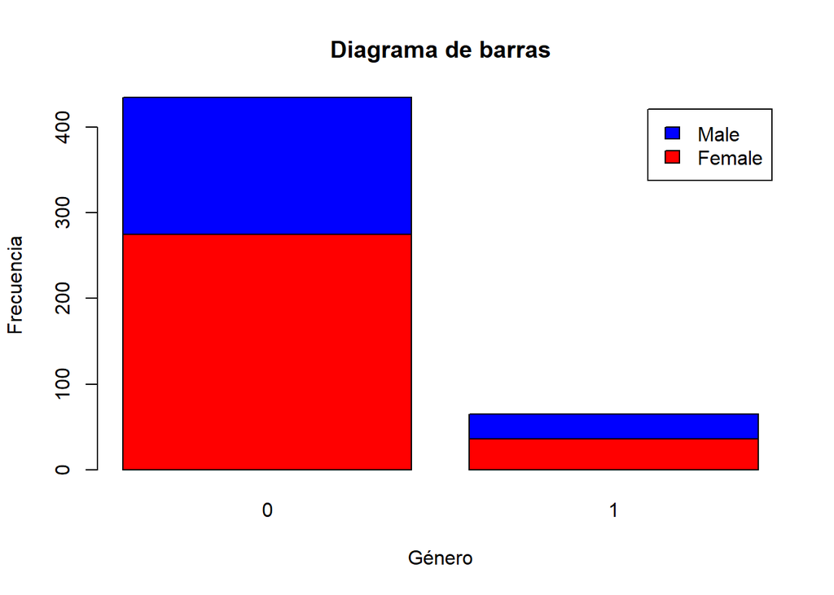

```r
# Cargar datos
df <- read.csv("new_columns.csv")

# Seleccionar columnas de interés
genero <- df$gender
diabetes <- df$diabetes

# Crear tabla de frecuencias
freq_table <- table(genero, diabetes)

# Crear diagrama de barras
barplot(freq_table, main = "Diagrama de barras", xlab = "Género", ylab = "Frecuencia", col = c("red", "blue"), legend = rownames(freq_table))
```

El gráfico generado muestra un diagrama de barras que representa la distribución de la variable “diabetes” en función del género de las personas en el conjunto de datos. La barra roja representa la frecuencia de mujeres y la barra azul representa la frecuencia de hombres. A partir de este gráfico, se pueden obtener varias conclusiones. Primero, se puede observar que la frecuencia de personas no diabéticas es mayor que la frecuencia de personas diabéticas en ambos géneros, pero en especial en el género femenino. Además, la diferencia entre la frecuencia de personas no diabéticas y diabéticas es mayor en el género femenino que en el género masculino. Otra conclusión que se puede obtener es que la distribución de la variable diabetes no es uniforme en función del género, lo que sugiere que el género puede estar relacionado con la presencia de diabetes. Sin embargo, para establecer una relación precisa se necesitaría realizar un análisis estadístico más completo y riguroso que permita determinar si esta diferencia es estadísticamente significativa o no.

Realizar histograma

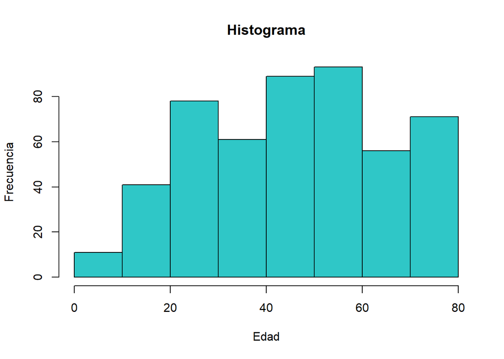

```r
# Cargar datos
df <- read.csv("new_columns.csv")

# Seleccionar columna de interés
edad <- df$age

# Crear histograma
hist(edad, main = "Histograma", xlab = "Edad", ylab = "Frecuencia", col = "#2fc7c7")
```

### Histograma con separaciones de intervalos de 10 en 10 unidades

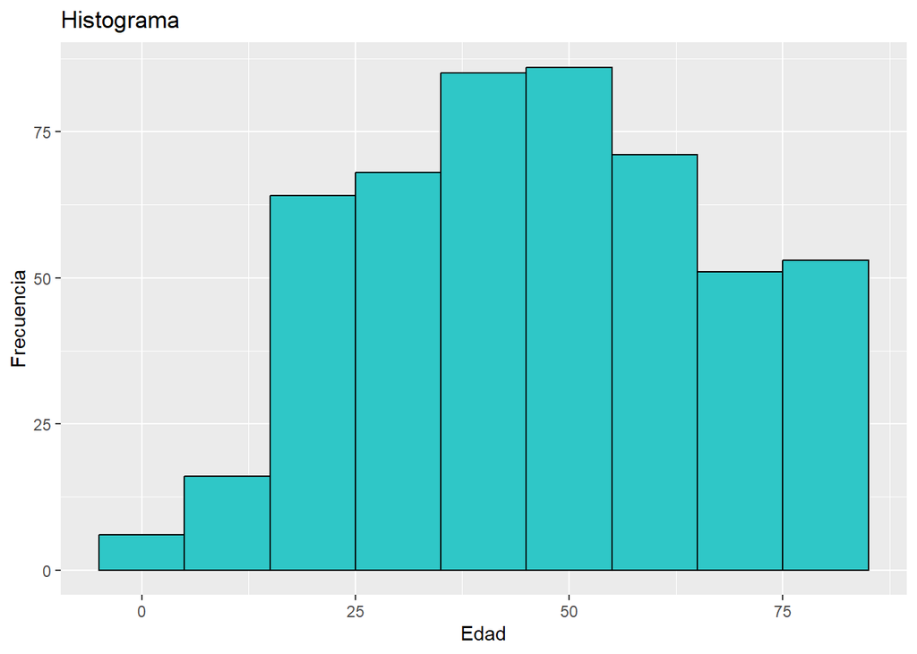

```r
# Cargar paquete ggplot2
library(ggplot2)

# Cargar datos
df <- read.csv("new_columns.csv")

# Crear histograma con intervalos de 10 en 10
ggplot(df, aes(x = age)) +
  geom_histogram(binwidth = 10, color = "black", fill = "#2fc7c7") +
  labs(title = "Histograma", x = "Edad", y = "Frecuencia")
```

Realizar diagrama de caja

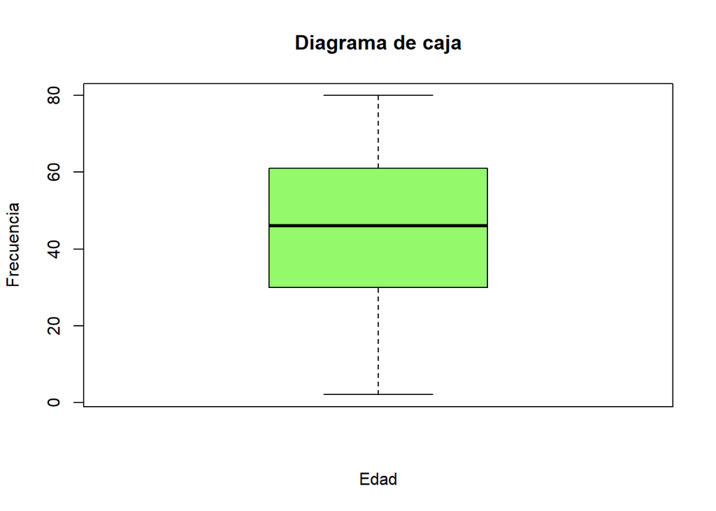

```r
# Cargar datos
df <- read.csv("new_columns.csv")

# Seleccionar columna de interés
edad <- df$age

# Crear diagrama de caja
boxplot(edad, main = "Diagrama de caja", xlab = "Edad", ylab = "Frecuencia", col = "#94fa6b")
```

El diagrama de cajas y bigotes permite visualizar la distribución de los datos de la variable “edad”. Los datos se distribuyen simétricamente alrededor de la mediana, que está representada por la línea que divide la caja en dos. La mayoría de los valores se encuentran dentro de la caja, que se extiende desde el primer cuartil (Q1) hasta el tercer cuartil (Q3). La longitud de la caja indica la dispersión intercuartílica de los datos. Los bigotes representan la dispersión total de los datos, excluyendo los valores atípicos (outliers) que se representan mediante puntos fuera de los bigotes. En este caso, no hay valores atípicos y los bigotes se extienden hasta los valores mínimo y máximo de la variable “edad”. En general, el diagrama de cajas y bigotes indica que la distribución de la variable “edad” es relativamente simétrica y no tiene valores atípicos, aunque se puede apreciar cierta concentración de valores en torno a la mediana.

Realizar diagrama de dispersión

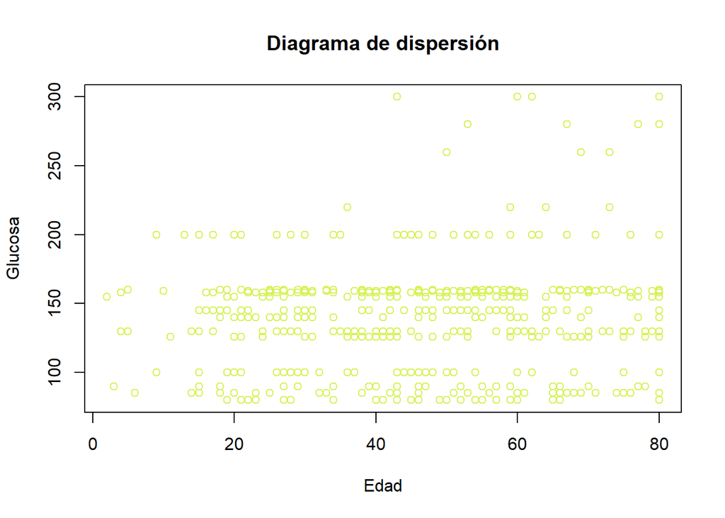

```r
# Cargar datos
df <- read.csv("new_columns.csv")

# Seleccionar columnas de interés
edad <- df$age
glucosa <- df$blood_glucose_level

# Crear diagrama de dispersión
plot(edad, glucosa, main = "Diagrama de dispersión", xlab = "Edad", ylab = "Glucosa", col = "#d5f256")
```

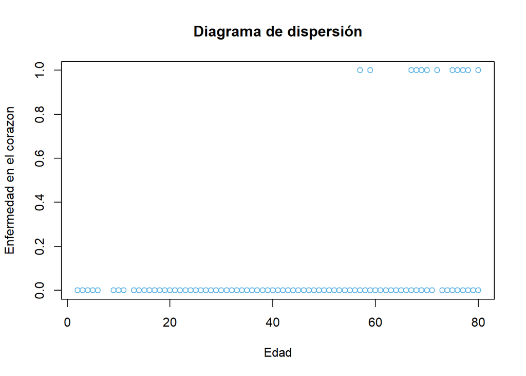

```r
# Cargar datos
df <- read.csv("new_columns.csv")

# Seleccionar columnas de interés
edad <- df$age
glucosa <- df$heart_disease

# Crear diagrama de dispersión
plot(edad, glucosa, main = "Diagrama de dispersión", xlab = "Edad", ylab = "Enfermedad en el corazon", col = "#62b4e4")
```

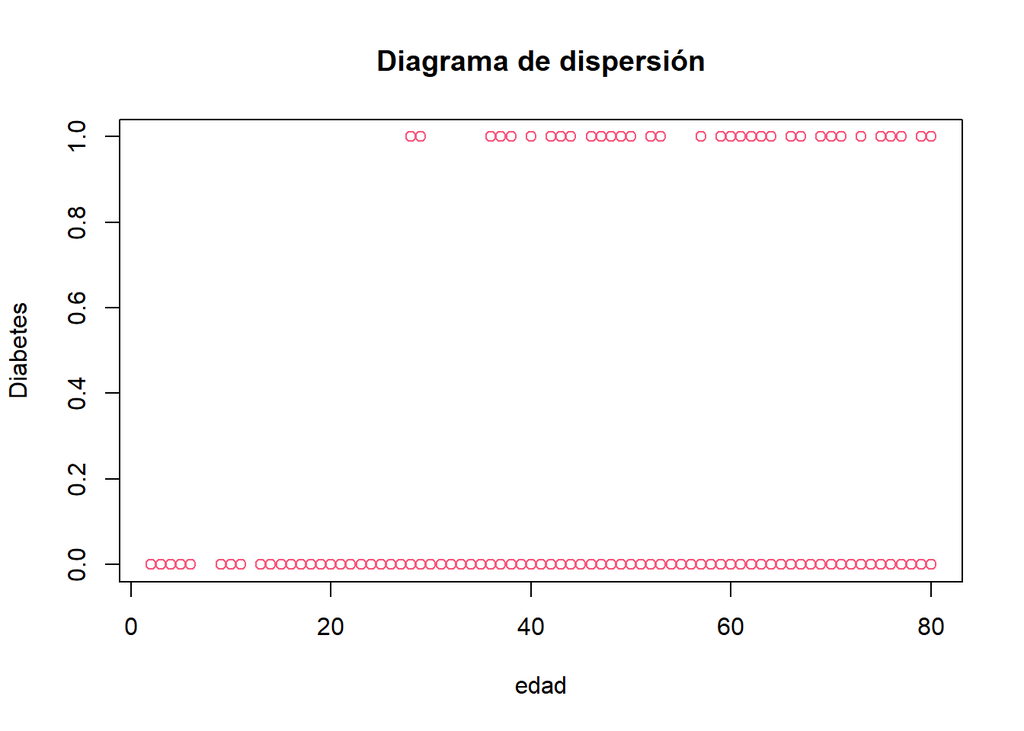

```r
# Cargar datos
df <- read.csv("new_columns.csv")

# Seleccionar columnas de interés
edad <- df$age
glucosa <- df$diabetes

# Crear diagrama de dispersión
plot(edad, glucosa, main = "Diagrama de dispersión", xlab = "edad", ylab = "Diabetes", col = "#f9567c")
```

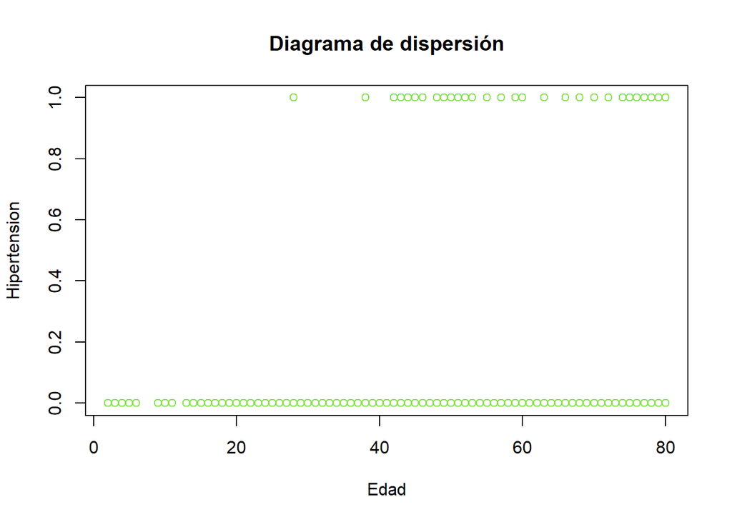

```r
# Cargar datos
df <- read.csv("new_columns.csv")

# Seleccionar columnas de interés
edad <- df$age
glucosa <- df$hypertension

# Crear diagrama de dispersión
plot(edad, glucosa, main = "Diagrama de dispersión", xlab = "Edad", ylab = "Hipertension", col = "#86e14e")
```

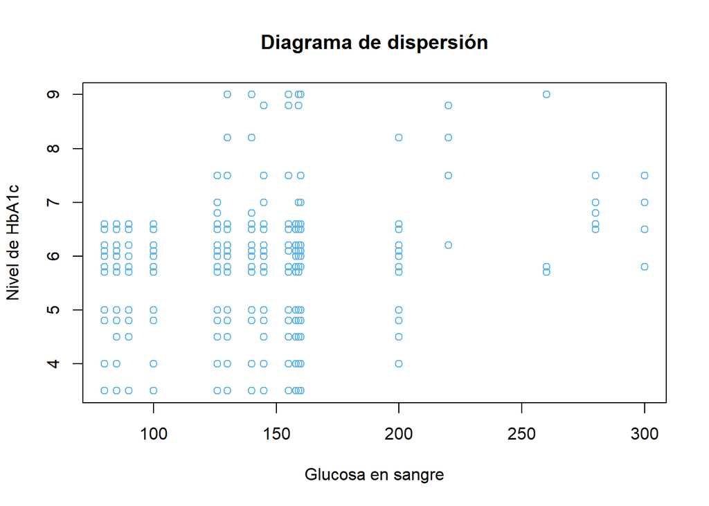

```r
# Cargar datos
df <- read.csv("new_columns.csv")

# Seleccionar columnas de interés
edad <- df$blood_glucose_level
glucosa <- df$HbA1c_level

# Crear diagrama de dispersión
plot(edad, glucosa, main = "Diagrama de dispersión", xlab = "Glucosa en sangre", ylab = "Nivel de HbA1c", col = "#62b4e4")
```

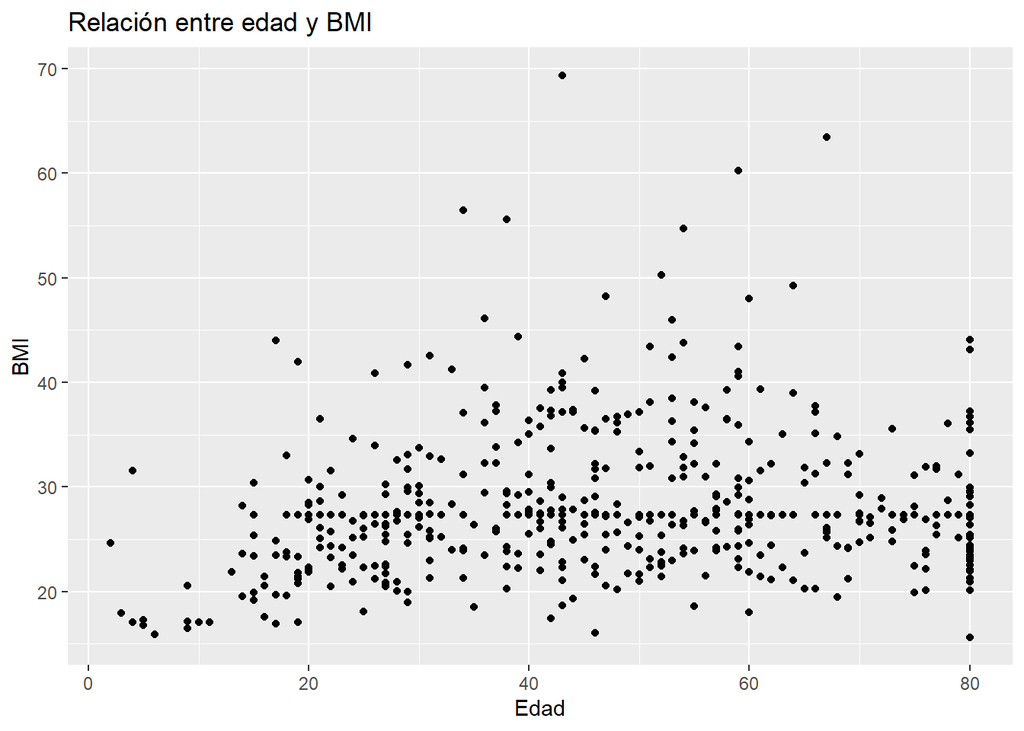

```r
library(ggplot2)

# Cargar datos
df <- read.csv("new_columns.csv")

# Crear gráfico de dispersión
ggplot(df, aes(x = age, y = bmi)) +
  geom_point() +
  labs(title = "Relación entre edad y BMI", x = "Edad", y = "BMI")
```

El gráfico de dispersión muestra una relación aparente entre la edad y el índice de masa corporal (BMI), donde se puede observar que a medida que aumenta la edad, también aumenta el BMI en general. Sin embargo, es importante tener en cuenta que el gráfico solo muestra una correlación entre estas dos variables y no necesariamente una relación causal directa. Además, hay puntos dispersos en el gráfico que indican que la relación no es completamente lineal y que hay otros factores que influyen en el BMI de una persona. Por lo tanto, es importante realizar un análisis más detallado y considerar otros factores relevantes antes de sacar conclusiones definitivas.

Realizar diagrama de sectores

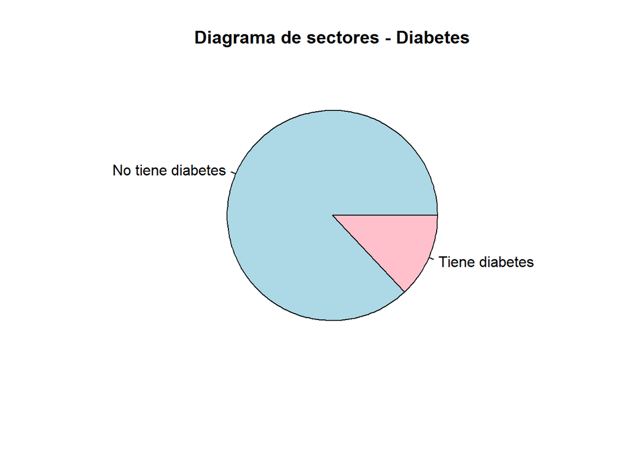

```r
datos <- read.csv("new_columns.csv")
tabla <- table(datos$diabetes)
pie(tabla, main="Diagrama de sectores - Diabetes", labels=c("No tiene diabetes", "Tiene diabetes"), col=c("lightblue", "pink"))
```

Construir un modelo de regresion lineal

### Ejemplo 1: Relación entre edad y niveles de glucosa en sangre

```r
# Cargar datos
df <- read.csv("new_columns.csv")

# Seleccionar columnas de interés
edad <- df$age
glucosa <- df$blood_glucose_level

# Crear modelo de regresión lineal
modelo <- lm(glucosa ~ edad, data = df)

# Ver el resumen del modelo
summary(modelo)
```

```
##
## Call:
## lm(formula = glucosa ~ edad, data = df)
##
## Residuals:
##     Min      1Q  Median      3Q     Max
## -68.684 -19.836   4.845  17.800 160.285
##
## Coefficients:
##              Estimate Std. Error t value Pr(>|t|)
## (Intercept) 129.29254    4.46107   28.98   <2e-16 ***
## edad          0.24239    0.08783    2.76    0.006 **
## ---
## Signif. codes:  0 '***' 0.001 '**' 0.01 '*' 0.05 '.' 0.1 ' ' 1
##
## Residual standard error: 38.85 on 498 degrees of freedom
## Multiple R-squared:  0.01506,    Adjusted R-squared:  0.01309
## F-statistic: 7.616 on 1 and 498 DF,  p-value: 0.005998
```

### Ejemplo 2: Relación entre edad y BMI

```r
# Cargar datos
df <- read.csv("new_columns.csv")

# Ajustar modelo de regresión lineal
modelo <- lm(bmi ~ age, data = df)

# Ver el resumen del modelo
summary(modelo)
```

```
##
## Call:
## lm(formula = bmi ~ age, data = df)
##
## Residuals:
##     Min      1Q  Median      3Q     Max
## -14.317  -4.591  -1.285   2.446  41.330
##
## Coefficients:
##             Estimate Std. Error t value Pr(>|t|)
## (Intercept) 25.80079    0.80112  32.206  < 2e-16 ***
## age          0.05208    0.01577   3.302  0.00103 **
## ---
## Signif. codes:  0 '***' 0.001 '**' 0.01 '*' 0.05 '.' 0.1 ' ' 1
##
## Residual standard error: 6.976 on 498 degrees of freedom
## Multiple R-squared:  0.02143,    Adjusted R-squared:  0.01946
## F-statistic:  10.9 on 1 and 498 DF,  p-value: 0.001029
```

```r
library(dplyr)
library(tidyr)
library(purrr)
library(broom)
```

```r
library(kableExtra)

# Construimos un data frame con el ajuste de los modelos.
modelos <- tibble(
  Lineal = list(lm(age ~ bmi, df)),
  Cuadratico = list(lm(age ~ bmi + I(bmi^2), df)),
  Exponencial = list(lm(log(age) ~ bmi, df)),
  Logaritmico = list(lm(age ~ log(bmi), df)),
  Potencial = list(lm(log(age) ~ log(bmi), df)),
  Inverso = list(lm(age ~ I(1/bmi), df)),
  Sigmoidal = list(lm(log(age) ~ I(1/bmi), df))
) %>%
  # Reestructuramos el data frame para tener todos los modelos en la misma columna.
  pivot_longer(everything(), names_to = "Tipo_Modelo", values_to = "Modelo") %>%
  # Obtenemos un resumen del ajuste de cada modelo en formato organizado (se obtiene una lista con los parámetros que describen el ajuste de cada modelo).
  mutate(Resumen = map(Modelo, glance)) %>%
  # Desanidamos el resumen (se obtiene una columna para cada parámetro del resumen del ajuste de los modelos).
  unnest(Resumen) %>%
  # Ordenamos el data frame por el coeficiente de determinación.
  arrange(-r.squared)

modelos %>%
  select(Tipo_Modelo, r.squared) %>%
  kable(col.names = c("Tipo de Modelo", "R²")) %>%
  kable_styling(full_width = F)
```

| Tipo de Modelo | R² |
| --- | --- |
| Sigmoidal | 0.0894080 |
| Potencial | 0.0676866 |
| Exponencial | 0.0469070 |
| Inverso | 0.0419197 |
| Cuadratico | 0.0403591 |
| Logaritmico | 0.0314840 |
| Lineal | 0.0214251 |

Los valores de R² son bajos en todos los casos, lo que indica que los modelos no explican la variabilidad de los datos de manera satisfactoria. En general, R² cercano a 1 indica un buen ajuste, mientras que valores cercanos a 0 indican un mal ajuste. La relación entre las variables no se ajusta bien a un modelo específico, esto sugieren que ninguno de estos modelos es adecuado para describir la relación entre las variables de los datos.

Construir un modelo de regresion no lineal

```r
# Cargar datos
df <- read.csv("new_columns.csv")

# Seleccionar columnas de interés
edad <- df$age
glucosa <- df$blood_glucose_level

# Crear modelo de regresión no lineal
modelo <- nls(glucosa ~ a * edad^b, data = df, start = list(a = 1, b = 1))
# Ver el resumen del modelo
summary(modelo)
```

```
##
## Formula: glucosa ~ a * edad^b
##
## Parameters:
##    Estimate Std. Error t value Pr(>|t|)
## a 112.59194   10.05401  11.199   <2e-16 ***
## b   0.05955    0.02352   2.532   0.0117 *
## ---
## Signif. codes:  0 '***' 0.001 '**' 0.01 '*' 0.05 '.' 0.1 ' ' 1
##
## Residual standard error: 38.89 on 498 degrees of freedom
##
## Number of iterations to convergence: 14
## Achieved convergence tolerance: 7.443e-07
```

Comparar distintos modelos de regresión.

```r
# Cargar datos
datos <- read.csv("new_columns.csv")

# Dividir los datos en conjunto de entrenamiento y prueba
set.seed(123) # Para reproducibilidad de resultados
muestra <- sample(2, nrow(datos), replace = TRUE, prob = c(0.7, 0.3))
entrenamiento <- datos[muestra == 1, ]
prueba <- datos[muestra == 2, ]
# Modelo de regresión lineal
modelo1 <- lm(blood_glucose_level ~ age + bmi + HbA1c_level, data = entrenamiento)

# Modelo de regresión no lineal
modelo2 <- nls(blood_glucose_level ~ a * age^b + c * bmi, data = entrenamiento,
               start = list(a = 1, b = 1, c = 1))
# Evaluar el rendimiento del modelo de regresión lineal
prediccion1 <- predict(modelo1, newdata = prueba)
R2_1 <- summary(modelo1)$r.squared
MSE_1 <- mean((prediccion1 - prueba$blood_glucose_level)^2)
MAE_1 <- mean(abs(prediccion1 - prueba$blood_glucose_level))

# Evaluar el rendimiento del modelo de regresión no lineal
prediccion2 <- predict(modelo2, newdata = prueba)
R2_2 <- summary(modelo2)$r.squared
MSE_2 <- mean((prediccion2 - prueba$blood_glucose_level)^2)
MAE_2 <- mean(abs(prediccion2 - prueba$blood_glucose_level))
# Comparar los modelos
resultados <- data.frame(Modelo = c("Regresión lineal", "Regresión no lineal"),
                         R2 = c(R2_1, R2_2),
                         MSE = c(MSE_1, MSE_2),
                         MAE = c(MAE_1, MAE_2))
print(resultados)
```

```
##                Modelo         R2      MSE      MAE
## 1    Regresión lineal 0.02197086 1530.129 28.51276
## 2 Regresión no lineal 0.02197086 1593.410 28.73651
```

R2_2 <- Esta línea de código calcula el coeficiente de determinación R cuadrado del modelo de regresión y lo almacena en la variable R2_2. El R cuadrado es una medida de qué tan bien el modelo se ajusta a los datos, y su valor oscila entre 0 y 1, donde 1 significa un ajuste perfecto y 0 significa que el modelo no explica la variabilidad en los datos. Un valor alto de R cuadrado indica que el modelo explica bien la variabilidad en los datos.

MSE_2 <- Esta línea de código calcula el error cuadrático medio (MSE) del modelo de regresión y lo almacena en la variable MSE_2. El MSE es una medida de la calidad del ajuste del modelo y mide la cantidad promedio de error al cuadrado entre las predicciones del modelo y los valores reales. Un MSE bajo indica que el modelo tiene un buen ajuste a los datos.

MAE_2 <- Esta línea de código calcula el error absoluto medio (MAE) del modelo de regresión y lo almacena en la variable MAE_2. El MAE es una medida de la precisión del modelo y mide la cantidad promedio de error absoluto entre las predicciones del modelo y los valores reales. Un MAE bajo indica que el modelo tiene una buena precisión en sus predicciones.

Hacer predicciones con un modelo de regresion

```r
# Cargar datos
df <- read.csv("new_columns.csv")

# Seleccionar columnas de interés
edad <- df$age
glucosa <- df$blood_glucose_level

# Crear modelo de regresión lineal
modelo <- lm(glucosa ~ edad, data = df)

# Hacer predicciones

# Predicción para una edad de 50 años
prediccion <- predict(modelo, data.frame(edad = 50))
print(prediccion)
```

```
##       1
## 141.412
```

```r
# Predicción para una edad de 60 años
prediccion <- predict(modelo, data.frame(edad = 60))
print(prediccion)
```

```
##        1
## 143.8359
```

```r
# Predicción para una edad de 70 años
prediccion <- predict(modelo, data.frame(edad = 70))
print(prediccion)
```

```
##        1
## 146.2598
```

Algunas conclusiones que se pueden extraer de esto son:

Relación lineal: El modelo de regresión lineal asume una relación lineal entre la variable de respuesta (glucosa en sangre) y la variable predictora (edad). Esto implica que se espera que los niveles de glucosa en sangre aumenten o disminuyan linealmente a medida que la edad aumenta o disminuye.

Predicciones individuales: Utilizando el modelo ajustado, se pueden hacer predicciones individuales sobre los niveles de glucosa en sangre para valores específicos de edad. En el ejemplo proporcionado, se realiza una predicción para una edad de 50 años y se obtiene un valor predicho de 141.412 para los niveles de glucosa en sangre.

Es importante tener en cuenta que estas conclusiones son específicas para el modelo de regresión lineal ajustado y los datos utilizados. Además, es fundamental realizar una evaluación adecuada del modelo, incluyendo el análisis de residuos y otras medidas de bondad de ajuste, antes de sacar conclusiones definitivas sobre la relación entre la edad y los niveles de glucosa en sangre.

Pivotar el Data Frame de formato ancho a largo

```r
library(tidyr)

# Pivoteo del Data Frame de formato ancho a largo
df_largo <- df %>%
  pivot_longer(cols = c("age", "hypertension", "bmi", "heart_disease", "diabetes"),
               names_to = "variable",
               values_to = "valor")

# Visualización del nuevo Data Frame
print(df_largo)
```

```
## # A tibble: 2,500 × 10
##    gender smoking_history HbA1c_level blood_glucose_…¹ edad_…² riesg…³ fumador estad…⁴ varia…⁵ valor
##    <chr>  <chr>                 <dbl>            <int>   <int> <chr>   <lgl>   <chr>   <chr>   <dbl>
##  1 Female never                   6.6              140     960 alto    FALSE   predia… age      80
##  2 Female never                   6.6              140     960 alto    FALSE   predia… hypert…   0
##  3 Female never                   6.6              140     960 alto    FALSE   predia… bmi      25.2
##  4 Female never                   6.6              140     960 alto    FALSE   predia… heart_…   1
##  5 Female never                   6.6              140     960 alto    FALSE   predia… diabet…   0
##  6 Male   never                   5.7              158     336 bajo    FALSE   predia… age      28
##  7 Male   never                   5.7              158     336 bajo    FALSE   predia… hypert…   0
##  8 Male   never                   5.7              158     336 bajo    FALSE   predia… bmi      27.3
##  9 Male   never                   5.7              158     336 bajo    FALSE   predia… heart_…   0
## 10 Male   never                   5.7              158     336 bajo    FALSE   predia… diabet…   0
## # … with 2,490 more rows, and abbreviated variable names ¹blood_glucose_level, ²edad_en_meses,
## #   ³riesgo_cardiovascular, ⁴estado_diabetes, ⁵variable
```

Comparar la distribución observada de una variable cuantitativa discreta con su distribución teórica a partir de sus percentiles.

```r
# Generar valores de la distribución observada
observada <- c(1, 2, 2, 3, 4, 4, 4, 5, 5, 6, 6, 6, 6, 7, 8, 9)

# Calcular los percentiles de la distribución observada
percentiles_obs <- quantile(observada, probs = seq(0, 1, 0.01))

# Especificar la distribución teórica y ajustarla a los datos
library(MASS)
```

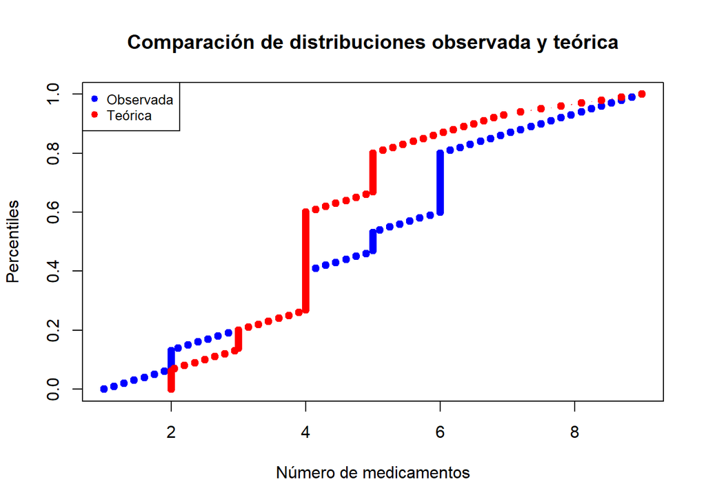

```r
ajuste_poisson <- fitdistr(observada, "Poisson")

# Generar una muestra aleatoria de la distribución teórica
muestra_poisson <- rpois(n = length(observada), lambda = ajuste_poisson$estimate)

# Calcular los percentiles de la distribución teórica generada
percentiles_teo <- quantile(muestra_poisson, probs = seq(0, 1, 0.01))

# Graficar las distribuciones observada y teórica en un mismo gráfico
plot(percentiles_obs, seq(0, 1, 0.01), type = "b", col = "blue", pch = 19,
     xlab = "Número de medicamentos", ylab = "Percentiles", main = "Comparación de distribuciones observada y teórica")
points(percentiles_teo, seq(0, 1, 0.01), type = "b", col = "red", pch = 19)
legend("topleft", legend = c("Observada", "Teórica"), col = c("blue", "red"), pch = 19, cex = 0.8)
```

Comparar la distribución observada de una variable cuantitativa continua con su distribución teórica a partir de sus percentiles

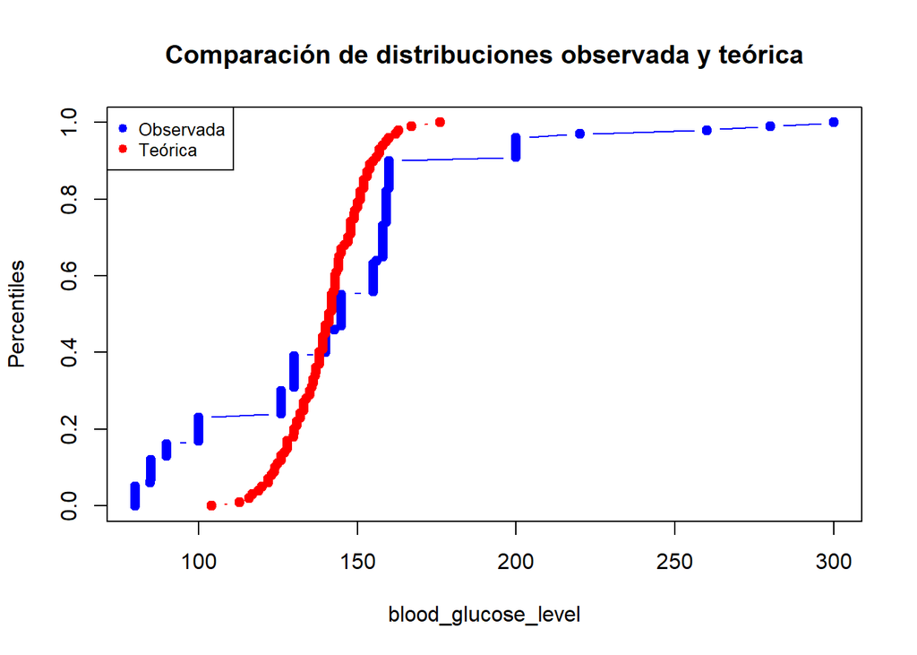

```r
# Cargar los datos
datos <- read.csv("new_columns.csv")

# Seleccionar la columna de interés
glucosa <- datos$blood_glucose_level

# Calcular los percentiles de la distribución observada
percentiles_obs <- quantile(glucosa, probs = seq(0, 1, 0.01))

# Especificar la distribución teórica y ajustarla a los datos
library(MASS)
ajuste_poisson <- fitdistr(glucosa, "Poisson")

# Generar una muestra aleatoria de la distribución teórica
muestra_poisson <- rpois(n = length(glucosa), lambda = ajuste_poisson$estimate)

# Calcular los percentiles de la distribución teórica generada
percentiles_teo <- quantile(muestra_poisson, probs = seq(0, 1, 0.01))

# Graficar las distribuciones observada y teórica en un mismo gráfico
plot(percentiles_obs, seq(0, 1, 0.01), type = "b", col = "blue", pch = 19,
     xlab = "blood_glucose_level", ylab = "Percentiles", main = "Comparación de distribuciones observada y teórica")
points(percentiles_teo, seq(0, 1, 0.01), type = "b", col = "red", pch = 19)
legend("topleft", legend = c("Observada", "Teórica"), col = c("blue", "red"), pch = 19, cex = 0.8)
```

Programar funciones para automatizar los análisis de datos

```r
# Definir función para calcular media y desviación estándar
calcular_estadisticas <- function(datos) {
  media <- mean(datos)
  desviacion_estandar <- sd(datos)
  return(list(media = media, desviacion_estandar = desviacion_estandar))
}

# Ejemplo de uso
datos <- c(1, 2, 3, 4, 5)
resultados <- calcular_estadisticas(datos)
print(resultados$media)
```

```
## [1] 3
```

```r
print(resultados$desviacion_estandar)
```

```
## [1] 1.581139
```

Simular un experimento aleatorio mediante la generación de números aleatorios a partir de una distribución discreta o continua y describir la variable resultante.

```r
# Establecer la semilla aleatoria para reproducibilidad
set.seed(123)

# Generar una muestra aleatoria de tamaño n
n <- 1000
age <- rnorm(n, mean = 46.782, sd = 19.80037)

# Verificar la media y desviación estándar de la muestra generada
media <- mean(age)
desviacion <- sd(age)

cat("Media:", media, "\n")
```

```
## Media: 47.10134
```

```r
cat("Desviación estándar:", desviacion, "\n")
```

```
## Desviación estándar: 19.63593
```

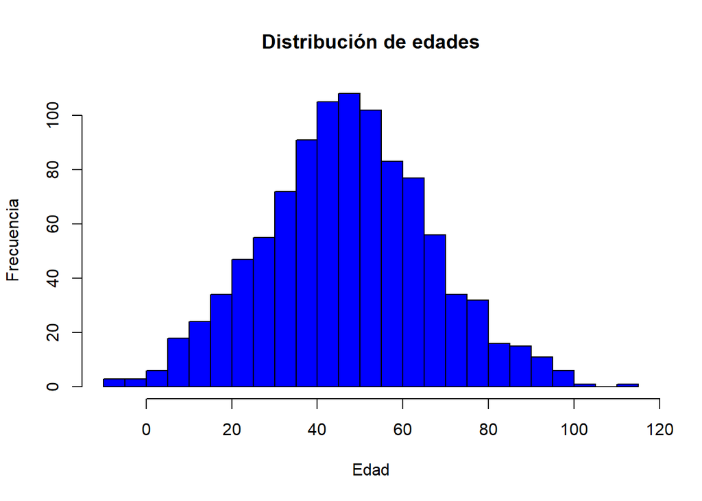

```r
# Graficar la distribución de la muestra generada
hist(age, breaks = 20, col = "blue", xlab = "Edad", ylab = "Frecuencia", main = "Distribución de edades")
```

*** Extra de los extras ***

Diagrama de barras agrupado por género y facetas por rango de edad

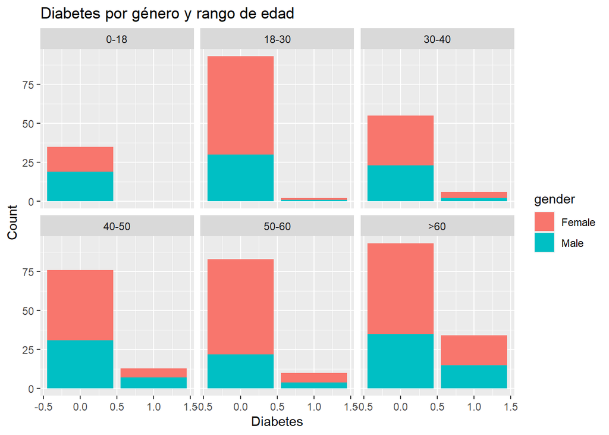

```r
library(ggplot2)

# Cargar datos
df <- read.csv("new_columns.csv")

# Crear una nueva columna para el rango de edad
df$rango_edad <- cut(df$age, breaks = c(0, 18, 30, 40, 50, 60, Inf),
                     labels = c("0-18", "18-30", "30-40", "40-50", "50-60", ">60"))

# Crear el gráfico de barras
ggplot(df, aes(x = diabetes, fill = gender)) +
  geom_bar() +
  facet_wrap(~ rango_edad) +
  labs(x = "Diabetes", y = "Count", title = "Diabetes por género y rango de edad")
```

Diagrama de cajas y bigotes agrupado por género y facetas por rango de edad

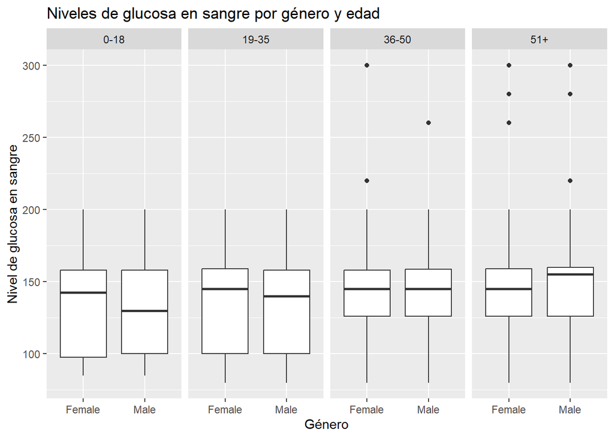

```r
library(ggplot2)

# Cargar datos
df <- read.csv("new_columns.csv")

# Crear variable rango_edad
df$rango_edad <- cut(df$age, breaks = c(0, 18, 35, 50, Inf),
                     labels = c("0-18", "19-35", "36-50", "51+"))

# Crear diagrama de cajas y bigotes
ggplot(df, aes(x = gender, y = blood_glucose_level)) +
  geom_boxplot() +
  facet_grid(. ~ rango_edad) +
  labs(title = "Niveles de glucosa en sangre por género y edad",
       x = "Género", y = "Nivel de glucosa en sangre")
```

Diagrama de sectores agrupado por género y facetas por rango de edad

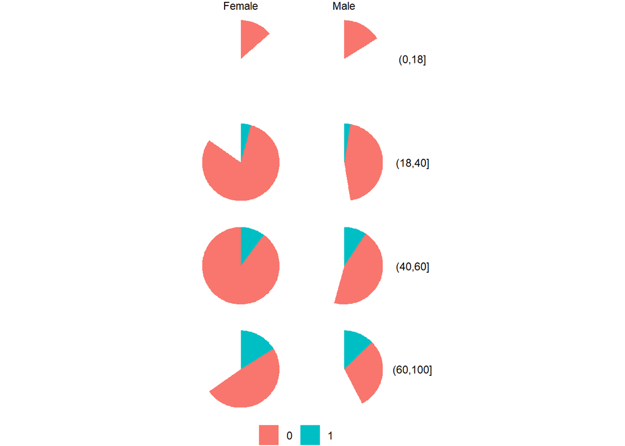

```r
df <- read.csv("new_columns.csv")
df$rango_edad <- cut(df$age, breaks = c(0, 18, 40, 60, 100))
df$diabetes <- as.factor(df$diabetes)

library(ggplot2)
ggplot(df, aes(x = "", fill = diabetes)) +
  geom_bar() +
  facet_grid(rows = vars(rango_edad), cols = vars(gender)) +
  coord_polar(theta = "y") +
  labs(fill = "") +
  theme_void() +
  theme(legend.position = "bottom")
```

Diagrama de lineas

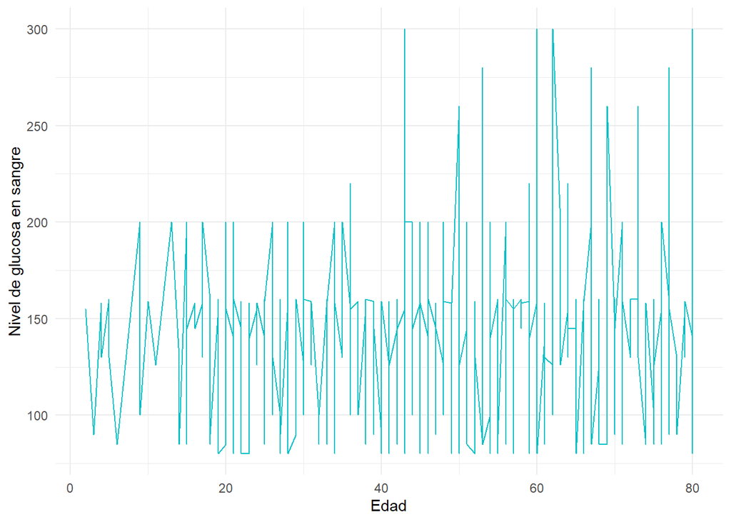

```r
library(ggplot2)

# Cargar los datos del archivo csv
datos <- read.csv("new_columns.csv")

# Crear el diagrama de líneas
ggplot(datos, aes(x=age, y=blood_glucose_level, group=1)) +
  geom_line(color="#00BFC4") +
  labs(x="Edad", y="Nivel de glucosa en sangre") +
  theme_minimal()
```

Diagrama de violin

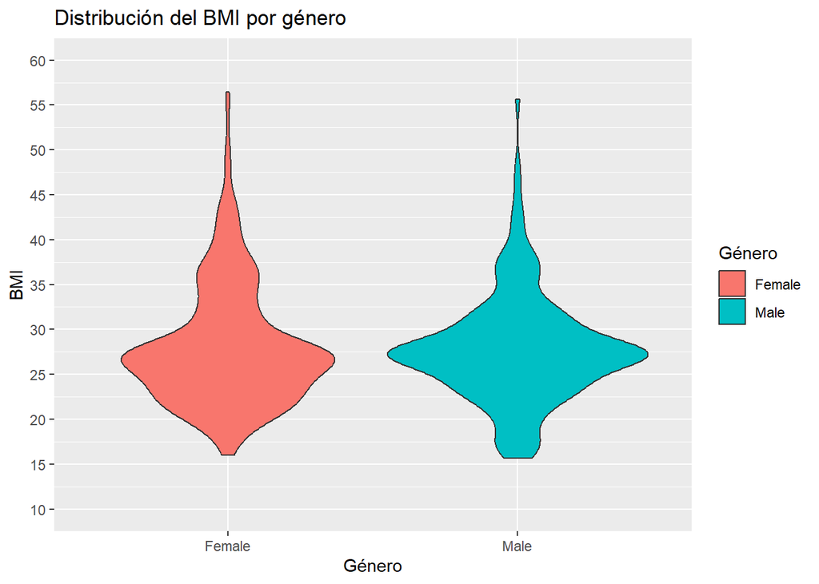

```r
library(ggplot2)

# Leer el archivo CSV
df <- read.csv("new_columns.csv")

# Generar el diagrama de violín
ggplot(df, aes(x = gender, y = bmi, fill = gender)) +
  geom_violin() +
  scale_y_continuous(limits = c(10, 60), breaks = seq(10, 60, 5)) +
  labs(x = "Género", y = "BMI", fill = "Género") +
  ggtitle("Distribución del BMI por género")
```

Diagrama de medias

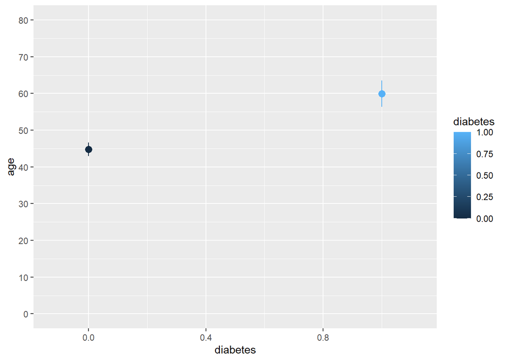

```r
library(ggplot2)
library(dplyr)

# Cargar datos desde CSV
df <- read.csv("new_columns.csv")

# Diagrama de medias
df %>%
  ggplot(aes(x = diabetes, y = age, colour = diabetes)) +
  # Puntos de medias
  stat_summary(fun="mean", size=3,  geom="point", position=position_dodge(width=0.25)) +
  # Intervalos de confianza para la media
  stat_summary(fun.data = function(x) mean_cl_normal(x, conf.int=0.95), geom = "pointrange", position=position_dodge(width=0.25)) +
  # Escala para el eje Y
  scale_y_continuous(limits=c(0, max(df$age)), breaks = seq(0, max(df$age), 10))
```

Diagrama de densidad

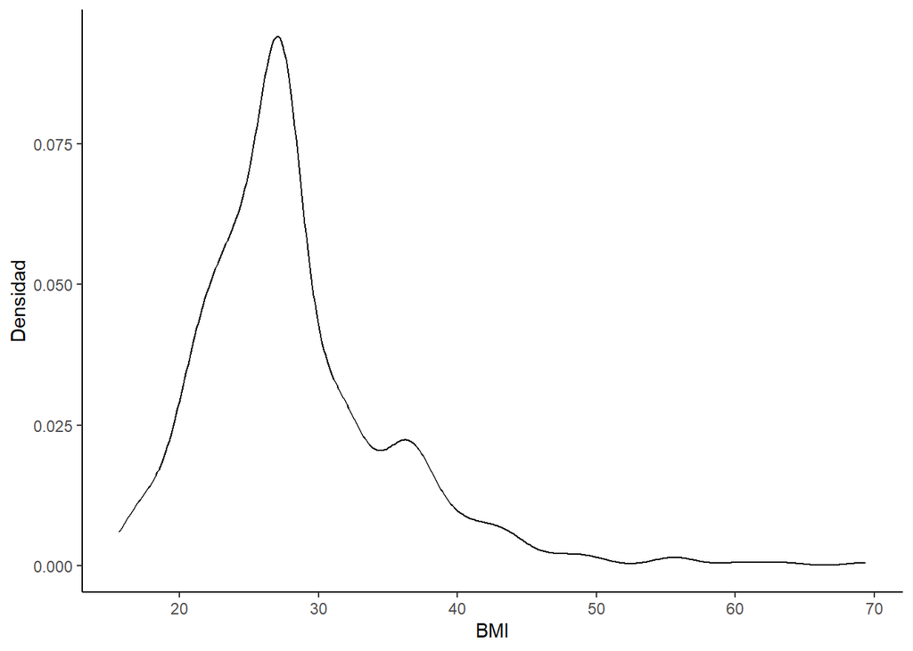

```r
library(ggplot2)

# Leer el archivo CSV con los datos
df <- read.csv("new_columns.csv")

# Crear el gráfico de densidad
ggplot(df, aes(x = bmi, fill = diabetes)) +
  geom_density(alpha = 0.5) +
  scale_fill_manual(values = c("blue", "red"), name = "Diabetes") +
  labs(x = "BMI", y = "Densidad") +
  theme_classic()
```

Diagrama de dispersión

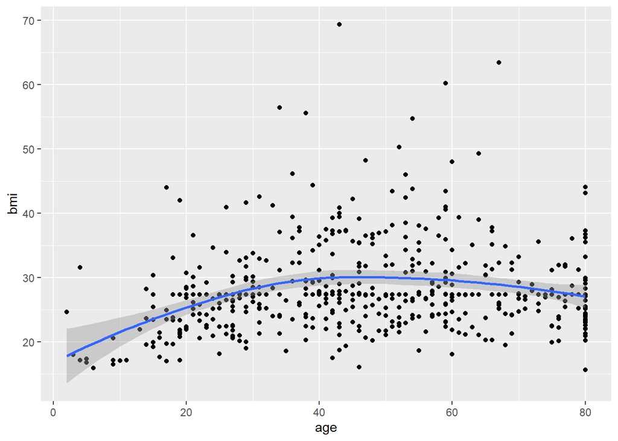

```r
library(ggplot2)
# Cargar el archivo CSV
df <- read.csv("new_columns.csv")
# Inicializar el gráfico con la edad en el atributo x y el bmi en el atributo y.
ggplot(df, aes(x = age, y = bmi)) +
  # Añadir la capa de puntos.
  geom_point() +
  # Añadir la capa de ajuste de regresión polinomial local loess.
  geom_smooth(method = "loess")
```

Diagrama de sectores agrupando por intervalos de 20 en 20 unidades

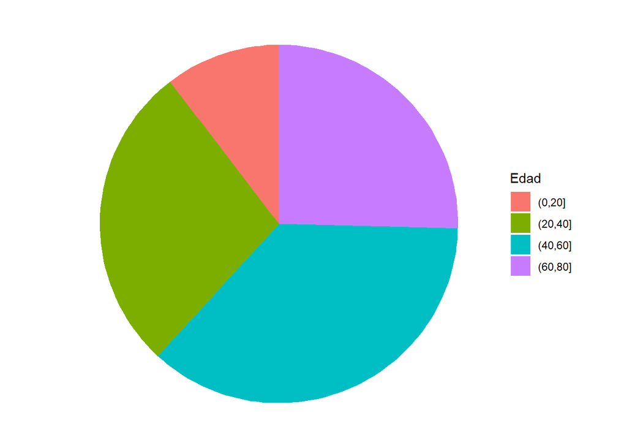

```r
# Leer archivo CSV
df <- read.csv("new_columns.csv")

# Crear columna con grupos de edad
df$grupo_edad <- cut(df$age, breaks = seq(0, 100, 20))

# Cargar paquete ggplot2
library(ggplot2)

# Crear diagrama de sectores
ggplot(df, aes(x = "", fill = grupo_edad)) +
  geom_bar(width = 1) +
  coord_polar(theta = "y") +
  labs(fill = "Edad") +
  theme_void()
```

Parte 2, trabajo 2º cruso

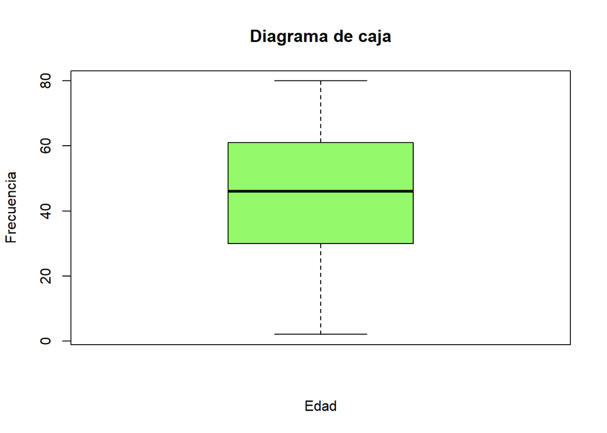

```r
# cuantos datos atipicos hay en cada variable

# Cargar datos
df <- read.csv("new_columns.csv")

# Seleccionar columnas de interés
edad <- df$age
glucosa <- df$blood_glucose_level
bmi <- df$bmi
HbA1c <- df$HbA1c_level

# Crear diagrama de caja
boxplot(edad, main = "Diagrama de caja", xlab = "Edad", ylab = "Frecuencia", col = "#94fa6b")
```

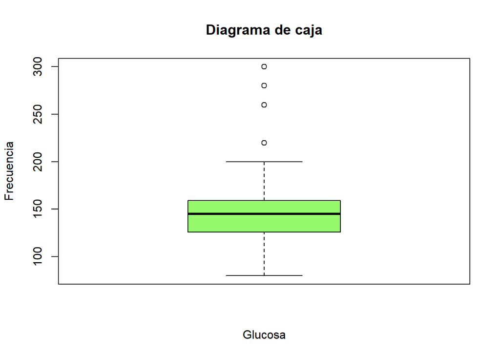

```r
boxplot(glucosa, main = "Diagrama de caja", xlab = "Glucosa", ylab = "Frecuencia", col = "#94fa6b")
```

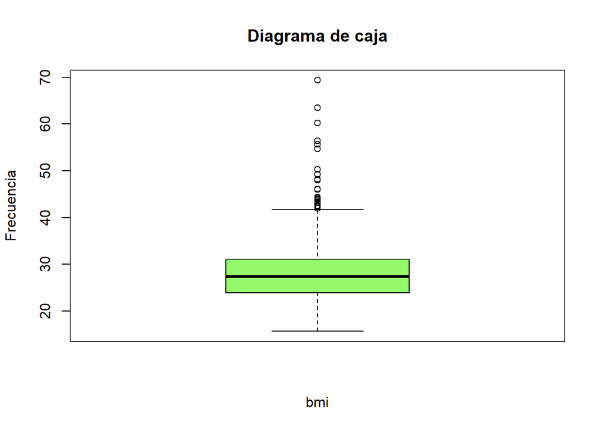

```r
boxplot(bmi, main = "Diagrama de caja", xlab = "bmi", ylab = "Frecuencia", col = "#94fa6b")
```

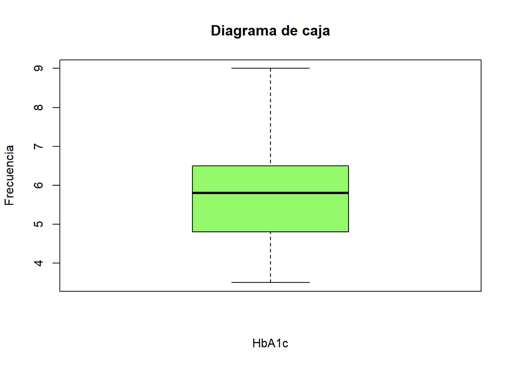

```r
boxplot(HbA1c, main = "Diagrama de caja", xlab = "HbA1c", ylab = "Frecuencia", col = "#94fa6b")
```

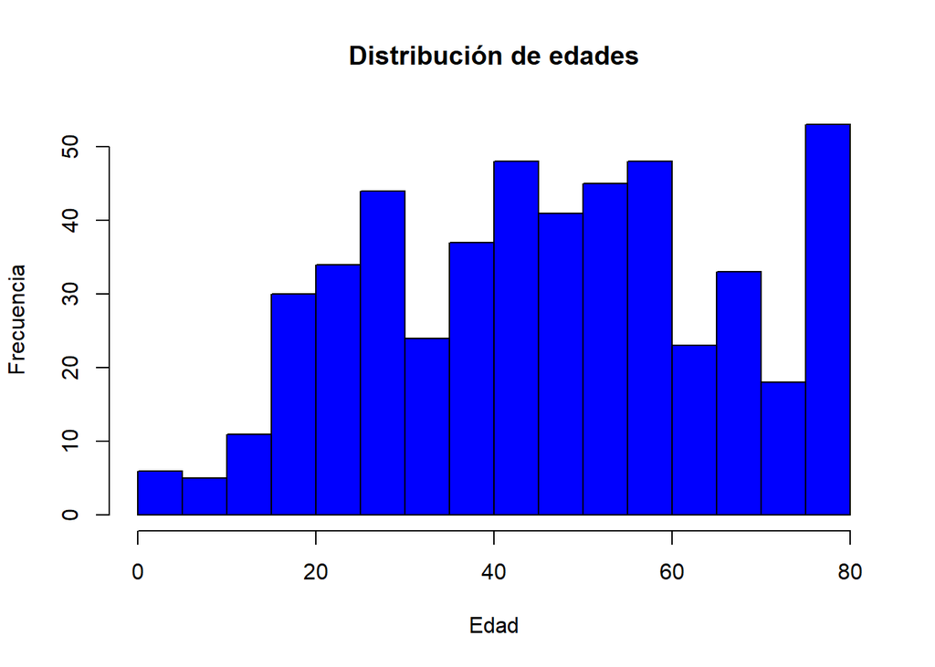

```r
# histograma
hist(edad, breaks = 20, col = "blue", xlab = "Edad", ylab = "Frecuencia", main = "Distribución de edades")
```

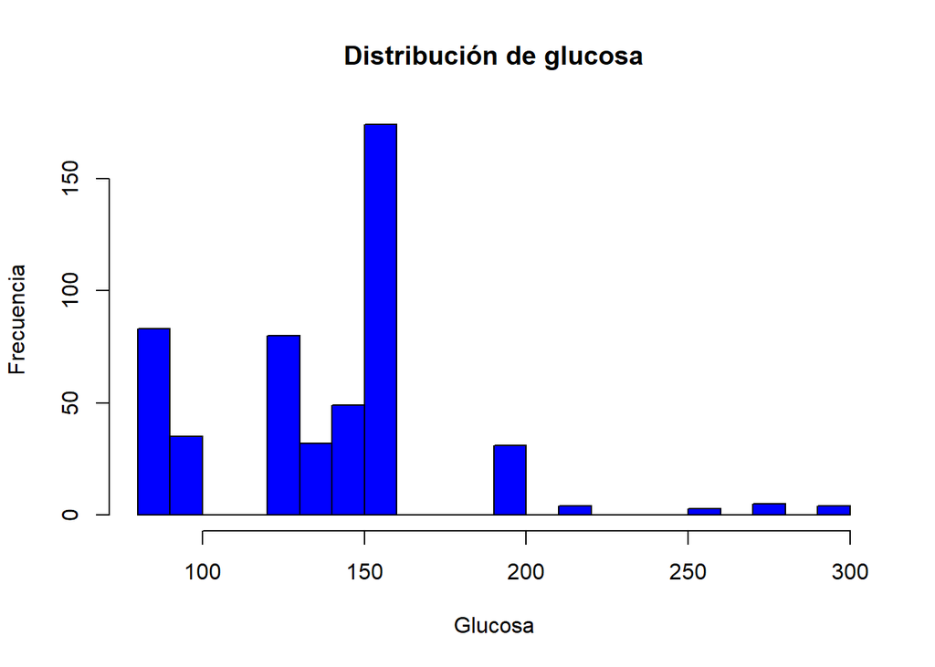

```r
hist(glucosa, breaks = 20, col = "blue", xlab = "Glucosa", ylab = "Frecuencia", main = "Distribución de glucosa")
```

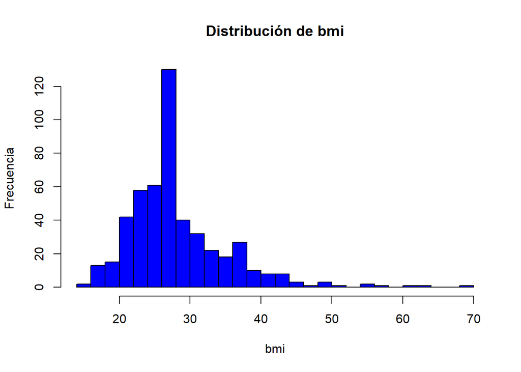

```r
hist(bmi, breaks = 20, col = "blue", xlab = "bmi", ylab = "Frecuencia", main = "Distribución de bmi")
```

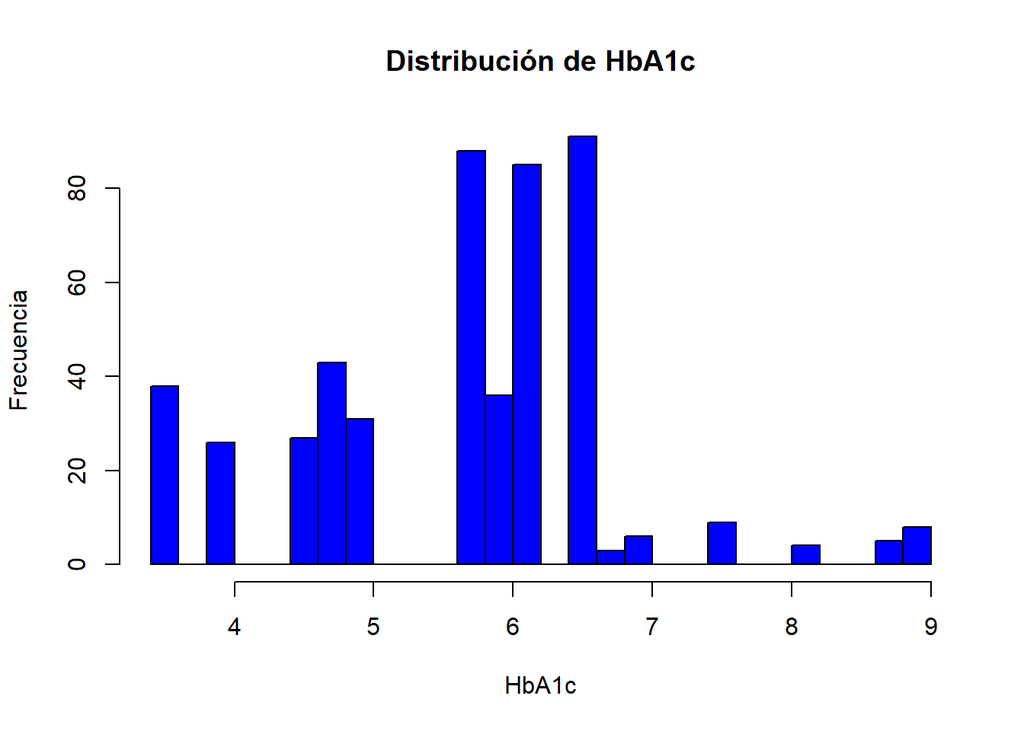

```r
hist(HbA1c, breaks = 20, col = "blue", xlab = "HbA1c", ylab = "Frecuencia", main = "Distribución de HbA1c")
```

```r
# cuantos datos atipicos hay en cada variable
# Edad
summary(edad)
```

```
##    Min. 1st Qu.  Median    Mean 3rd Qu.    Max.
##    2.00   30.00   46.00   46.78   61.00   80.00
```

```r
# Glucosa
summary(glucosa)
```

```
##    Min. 1st Qu.  Median    Mean 3rd Qu.    Max.
##    80.0   126.0   145.0   140.6   159.0   300.0
```

```r
# bmi
summary(bmi)
```

```
##    Min. 1st Qu.  Median    Mean 3rd Qu.    Max.
##   15.65   23.89   27.32   28.24   31.04   69.37
```

```r
# HbA1c
summary(HbA1c)
```

```
##    Min. 1st Qu.  Median    Mean 3rd Qu.    Max.
##   3.500   4.800   5.800   5.681   6.500   9.000
```

```r
#crear una tabla con la media y la varianza de cada variable

# Cargar datos
df <- read.csv("new_columns.csv")

# Seleccionar columnas de interés
edad <- df$age
glucosa <- df$blood_glucose_level
bmi <- df$bmi
HbA1c <- df$HbA1c_level

# Crear tabla con la media, la varianza y los datos atipicos de cada variable

# Edad
media_edad <- mean(edad)
varianza_edad <- var(edad)
datos_atipicos_edad <- length(boxplot.stats(edad)$out)

# Glucosa
media_glucosa <- mean(glucosa)
varianza_glucosa <- var(glucosa)
datos_atipicos_glucosa <- length(boxplot.stats(glucosa)$out)

# bmi
media_bmi <- mean(bmi)
varianza_bmi <- var(bmi)
datos_atipicos_bmi <- length(boxplot.stats(bmi)$out)

# HbA1c
media_HbA1c <- mean(HbA1c)
varianza_HbA1c <- var(HbA1c)
datos_atipicos_HbA1c <- length(boxplot.stats(HbA1c)$out)

# Crear tabla
tabla <- data.frame(media = c(media_edad, media_glucosa, media_bmi, media_HbA1c),
                    varianza = c(varianza_edad, varianza_glucosa, varianza_bmi, varianza_HbA1c),
                    datos_atipicos = c(datos_atipicos_edad, datos_atipicos_glucosa, datos_atipicos_bmi, datos_atipicos_HbA1c))
rownames(tabla) <- c("Edad", "Glucosa", "bmi", "HbA1c")
print(tabla)
```

```
##             media    varianza datos_atipicos
## Edad     46.78200  392.054585              0
## Glucosa 140.63200 1529.170918             16
## bmi      28.23726   49.635054             23
## HbA1c     5.68120    1.280568              0
```

La media es una medida estadística que representa el valor típico o promedio de un conjunto de datos. Se calcula sumando todos los valores en el conjunto y dividiendo el resultado por el número total de observaciones. La media es sensible a los valores extremos y proporciona una indicación central de la distribución de los datos. Es una medida de tendencia central ampliamente utilizada en estadísticas descriptivas.

La varianza es una medida de dispersión que cuantifica la extensión o dispersión de un conjunto de datos. Se calcula tomando la diferencia al cuadrado entre cada valor y la media, sumando estos cuadrados y dividiendo por el número total de observaciones. La varianza proporciona información sobre la variabilidad de los datos. Valores mayores de varianza indican mayor dispersión, mientras que valores menores indican menor dispersión. La raíz cuadrada de la varianza da lugar a la desviación estándar, otra medida común de dispersión.

Los valores atípicos, también conocidos como outliers en inglés, son puntos de datos que se desvían significativamente de la mayoría de los otros puntos en un conjunto de datos. Estos valores atípicos pueden tener un impacto desproporcionado en el análisis estadístico, ya que pueden afectar negativamente la precisión de ciertas estadísticas descriptivas y sesgar los resultados de pruebas estadísticas.

Edad:

Media: La edad promedio es de aproximadamente 46.78. Varianza: La varianza de la edad es de aproximadamente 392.05. Datos Atípicos: No se observan datos atípicos en la variable ‘Edad’.

Glucosa:

Media: La media de la glucosa es de alrededor de 140.63. Varianza: La varianza de la glucosa es de aproximadamente 1529.17. Datos Atípicos: Se identifican 16 datos atípicos en la variable ‘Glucosa’.

bmi (Índice de Masa Corporal):

Media: El bmi promedio es de alrededor de 28.24. Varianza: La varianza del bmi es de aproximadamente 49.64. Datos Atípicos: Se observan 23 datos atípicos en la variable ‘bmi’.

HbA1c:

Media: La media de HbA1c es de aproximadamente 5.68. Varianza: La varianza de HbA1c es de aproximadamente 1.28. Datos Atípicos: No se observan datos atípicos en la variable ‘HbA1c’.

Conclusiones Generales:

La edad parece tener una distribución sin datos atípicos, con una varianza moderada.

La glucosa muestra una mayor variabilidad (alta varianza) y se identifican datos atípicos, lo que podría indicar una mayor heterogeneidad en los niveles de glucosa.

El bmi tiene una varianza moderada y presenta un número considerable de datos atípicos, lo que sugiere variabilidad en los índices de masa corporal.

HbA1c muestra una distribución sin datos atípicos y una varianza relativamente baja.

Estas conclusiones proporcionan una visión general de la distribución y características estadísticas de las variables mencionadas. La presencia de datos atípicos y la variabilidad en las varianzas indican la necesidad de una evaluación más detallada y posiblemente la aplicación de técnicas específicas para abordar estos aspectos en el análisis de datos.

```r
# Calcular la correlación entre las variables
correlation_matrix <- cor(df[, c("age", "blood_glucose_level", "bmi", "HbA1c_level")])

# Imprimir la matriz de correlación
print("Matriz de Correlación:")
```

```
## [1] "Matriz de Correlación:"
```

```r
print(correlation_matrix)
```

```
##                           age blood_glucose_level       bmi HbA1c_level
## age                 1.0000000           0.1227322 0.1463730   0.1999892
## blood_glucose_level 0.1227322           1.0000000 0.0336463   0.1622594
## bmi                 0.1463730           0.0336463 1.0000000   0.1829127
## HbA1c_level         0.1999892           0.1622594 0.1829127   1.0000000
```

La matriz de correlación proporciona información sobre las relaciones lineales entre las variables analizadas. Cada valor en la matriz representa el coeficiente de correlación entre las dos variables correspondientes. Aquí está la interpretación de la matriz de correlación dada:

Interpretación:

Entre ‘age’ y las Otras Variables:

Existe una correlación positiva débil entre ‘age’ y ‘blood_glucose_level’ (0.12), ‘bmi’ (0.15), y ‘HbA1c_level’ (0.20). Esto sugiere que a medida que la edad aumenta, también tiende a aumentar ligeramente la glucosa en la sangre, el índice de masa corporal (bmi) y los niveles de HbA1c.

Conclusiones Generales:

Las correlaciones son relativamente bajas, lo que sugiere que las variables tienen asociaciones lineales débiles entre sí. La fuerza y la dirección de la correlación proporcionan información sobre cómo las variables cambian juntas. En este caso, las asociaciones son, en su mayoría, débiles. Es importante tener en cuenta que la correlación no implica causalidad, y otras variables o factores podrían influir en estas relaciones. Además, las correlaciones no capturan relaciones no lineales.

Estimación por intervalos de confianza al 95% de las medias poblacionales, varianzas poblacionales, diferencia de medias poblacionales y cociente de varianzas poblacionales. Análisis de los resultados.

# medias poblacionales al 95%

```r
# Cargar datos
df <- read.csv("new_columns.csv")
# Seleccionar columnas de interés
edad <- df$age
glucosa <- df$blood_glucose_level
bmi <- df$bmi
HbA1c <- df$HbA1c_level
# Estimación por intervalos de confianza al 95% de las medias poblacionales, varianzas poblacionales, diferencia de medias poblacionales y cociente de varianzas poblacionales. Análisis de los resultados.
# Edad
IC_edad_95 <- t.test(edad, conf.level = 0.95)
IC_edad_95
```

```
##
##  One Sample t-test
##
## data:  edad
## t = 52.831, df = 499, p-value < 2.2e-16
## alternative hypothesis: true mean is not equal to 0
## 95 percent confidence interval:
##  45.04223 48.52177
## sample estimates:
## mean of x
##    46.782
```

```r
# Glucosa
IC_glucosa_95 <- t.test(glucosa, conf.level = 0.95)
IC_glucosa_95
```

```
##
##  One Sample t-test
##
## data:  glucosa
## t = 80.416, df = 499, p-value < 2.2e-16
## alternative hypothesis: true mean is not equal to 0
## 95 percent confidence interval:
##  137.1961 144.0679
## sample estimates:
## mean of x
##   140.632
```

```r
# bmi
IC_bmi_95 <- t.test(bmi, conf.level = 0.95)
IC_bmi_95
```

```
##
##  One Sample t-test
##
## data:  bmi
## t = 89.622, df = 499, p-value < 2.2e-16
## alternative hypothesis: true mean is not equal to 0
## 95 percent confidence interval:
##  27.61823 28.85629
## sample estimates:
## mean of x
##  28.23726
```

```r
# HbA1c
IC_HbA1c_95 <- t.test(HbA1c, conf.level = 0.95)
IC_HbA1c_95
```

```
##
##  One Sample t-test
##
## data:  HbA1c
## t = 112.26, df = 499, p-value < 2.2e-16
## alternative hypothesis: true mean is not equal to 0
## 95 percent confidence interval:
##  5.58177 5.78063
## sample estimates:
## mean of x
##    5.6812
```

# varianzas poblacionales al 95%

```r
# Para la variable edad
n_edad <- length(edad)
s2_edad <- var(edad)
k1_edad <- qchisq(0.975, n_edad-1, lower.tail = FALSE)
k2_edad <- qchisq(0.025, n_edad-1, lower.tail = FALSE)
ICVAR_edad_95 <- c(((n_edad-1)*s2_edad)/k2_edad, ((n_edad-1)*s2_edad)/k1_edad)
ICVAR_edad_95
```

```
## [1] 347.6171 445.6404
```

```r
# Para la variable glucosa
n_glucosa <- length(glucosa)
s2_glucosa <- var(glucosa)
k1_glucosa <- qchisq(0.975, n_glucosa-1, lower.tail = FALSE)
k2_glucosa <- qchisq(0.025, n_glucosa-1, lower.tail = FALSE)
ICVAR_glucosa_95 <- c(((n_glucosa-1)*s2_glucosa)/k2_glucosa, ((n_glucosa-1)*s2_glucosa)/k1_glucosa)
ICVAR_glucosa_95
```

```
## [1] 1355.847 1738.177
```

```r
# Para la variable bmi
n_bmi <- length(bmi)
s2_bmi <- var(bmi)
k1_bmi <- qchisq(0.975, n_bmi-1, lower.tail = FALSE)
k2_bmi <- qchisq(0.025, n_bmi-1, lower.tail = FALSE)
ICVAR_bmi_95 <- c(((n_bmi-1)*s2_bmi)/k2_bmi, ((n_bmi-1)*s2_bmi)/k1_bmi)
ICVAR_bmi_95
```

```
## [1] 44.00916 56.41914
```

```r
# Para la variable HbA1c
n_HbA1c <- length(HbA1c)
s2_HbA1c <- var(HbA1c)
k1_HbA1c <- qchisq(0.975, n_HbA1c-1, lower.tail = FALSE)
k2_HbA1c <- qchisq(0.025, n_HbA1c-1, lower.tail = FALSE)
ICVAR_HbA1c_95 <- c(((n_HbA1c-1)*s2_HbA1c)/k2_HbA1c, ((n_HbA1c-1)*s2_HbA1c)/k1_HbA1c)
ICVAR_HbA1c_95
```

```
## [1] 1.135421 1.455595
```

## medias poblacionales al 80%

```r
# Cargar datos
df <- read.csv("new_columns.csv")
# Seleccionar columnas de interés
edad <- df$age
glucosa <- df$blood_glucose_level
bmi <- df$bmi
HbA1c <- df$HbA1c_level

# Estimación por intervalos de confianza al 80% de las medias poblacionales
IC_edad_80 <- t.test(edad, conf.level = 0.80)
IC_edad_80
```

```
##
##  One Sample t-test
##
## data:  edad
## t = 52.831, df = 499, p-value < 2.2e-16
## alternative hypothesis: true mean is not equal to 0
## 80 percent confidence interval:
##  45.64568 47.91832
## sample estimates:
## mean of x
##    46.782
```

```r
IC_glucosa_80 <- t.test(glucosa, conf.level = 0.80)
IC_glucosa_80
```

```
##
##  One Sample t-test
##
## data:  glucosa
## t = 80.416, df = 499, p-value < 2.2e-16
## alternative hypothesis: true mean is not equal to 0
## 80 percent confidence interval:
##  138.3878 142.8762
## sample estimates:
## mean of x
##   140.632
```

```r
IC_bmi_80 <- t.test(bmi, conf.level = 0.80)
IC_bmi_80
```

```
##
##  One Sample t-test
##
## data:  bmi
## t = 89.622, df = 499, p-value < 2.2e-16
## alternative hypothesis: true mean is not equal to 0
## 80 percent confidence interval:
##  27.83294 28.64158
## sample estimates:
## mean of x
##  28.23726
```

```r
IC_HbA1c_80 <- t.test(HbA1c, conf.level = 0.80)
IC_HbA1c_80
```

```
##
##  One Sample t-test
##
## data:  HbA1c
## t = 112.26, df = 499, p-value < 2.2e-16
## alternative hypothesis: true mean is not equal to 0
## 80 percent confidence interval:
##  5.616258 5.746142
## sample estimates:
## mean of x
##    5.6812
```

# varianzas poblacionales al 80%

```r
# Para la variable edad
n_edad <- length(edad)
s2_edad <- var(edad)
k1_edad <- qchisq(0.90, n_edad-1, lower.tail = FALSE)
k2_edad <- qchisq(0.10, n_edad-1, lower.tail = FALSE)
ICVAR_edad_80 <- c(((n_edad-1)*s2_edad)/k2_edad, ((n_edad-1)*s2_edad)/k1_edad)
ICVAR_edad_80
```

```
## [1] 362.3615 426.2515
```

```r
# Para la variable glucosa
n_glucosa <- length(glucosa)
s2_glucosa <- var(glucosa)
k1_glucosa <- qchisq(0.90, n_glucosa-1, lower.tail = FALSE)
k2_glucosa <- qchisq(0.10, n_glucosa-1, lower.tail = FALSE)
ICVAR_glucosa_80 <- c(((n_glucosa-1)*s2_glucosa)/k2_glucosa, ((n_glucosa-1)*s2_glucosa)/k1_glucosa)
ICVAR_glucosa_80
```

```
## [1] 1413.356 1662.553
```

```r
# Para la variable bmi
n_bmi <- length(bmi)
s2_bmi <- var(bmi)
k1_bmi <- qchisq(0.90, n_bmi-1, lower.tail = FALSE)
k2_bmi <- qchisq(0.10, n_bmi-1, lower.tail = FALSE)
ICVAR_bmi_80 <- c(((n_bmi-1)*s2_bmi)/k2_bmi, ((n_bmi-1)*s2_bmi)/k1_bmi)
ICVAR_bmi_80
```

```
## [1] 45.87583 53.96446
```

```r
# Para la variable HbA1c
n_HbA1c <- length(HbA1c)
s2_HbA1c <- var(HbA1c)
k1_HbA1c <- qchisq(0.90, n_HbA1c-1, lower.tail = FALSE)
k2_HbA1c <- qchisq(0.10, n_HbA1c-1, lower.tail = FALSE)
ICVAR_HbA1c_80 <- c(((n_HbA1c-1)*s2_HbA1c)/k2_HbA1c, ((n_HbA1c-1)*s2_HbA1c)/k1_HbA1c)
ICVAR_HbA1c_80
```

```
## [1] 1.183581 1.392265
```

# medias poblacionales al 20%

```r
# Cargar datos
df <- read.csv("new_columns.csv")
# Seleccionar columnas de interés
edad <- df$age
glucosa <- df$blood_glucose_level
bmi <- df$bmi
HbA1c <- df$HbA1c_level

# Estimación por intervalos de confianza al 20% de las medias poblacionales
IC_edad_20 <- t.test(edad, conf.level = 0.20)
IC_edad_20
```

```
##
##  One Sample t-test
##
## data:  edad
## t = 52.831, df = 499, p-value < 2.2e-16
## alternative hypothesis: true mean is not equal to 0
## 20 percent confidence interval:
##  46.55754 47.00646
## sample estimates:
## mean of x
##    46.782
```

```r
IC_glucosa_20 <- t.test(glucosa, conf.level = 0.20)
IC_glucosa_20
```

```
##
##  One Sample t-test
##
## data:  glucosa
## t = 80.416, df = 499, p-value < 2.2e-16
## alternative hypothesis: true mean is not equal to 0
## 20 percent confidence interval:
##  140.1887 141.0753
## sample estimates:
## mean of x
##   140.632
```

```r
IC_bmi_20 <- t.test(bmi, conf.level = 0.20)
IC_bmi_20
```

```
##
##  One Sample t-test
##
## data:  bmi
## t = 89.622, df = 499, p-value < 2.2e-16
## alternative hypothesis: true mean is not equal to 0
## 20 percent confidence interval:
##  28.15739 28.31713
## sample estimates:
## mean of x
##  28.23726
```

```r
IC_HbA1c_20 <- t.test(HbA1c, conf.level = 0.20)
IC_HbA1c_20
```

```
##
##  One Sample t-test
##
## data:  HbA1c
## t = 112.26, df = 499, p-value < 2.2e-16
## alternative hypothesis: true mean is not equal to 0
## 20 percent confidence interval:
##  5.668372 5.694028
## sample estimates:
## mean of x
##    5.6812
```

# varianzas poblacionales al 20%

```r
# Para la variable edad
n_edad <- length(edad)
s2_edad <- var(edad)
k1_edad <- qchisq(0.90, n_edad-1, lower.tail = FALSE)
k2_edad <- qchisq(0.80, n_edad-1, lower.tail = FALSE)
ICVAR_edad_20 <- c(((n_edad-1)*s2_edad)/k2_edad, ((n_edad-1)*s2_edad)/k1_edad)
ICVAR_edad_20
```

```
## [1] 414.2739 426.2515
```

```r
# Para la variable glucosa
n_glucosa <- length(glucosa)
s2_glucosa <- var(glucosa)
k1_glucosa <- qchisq(0.90, n_glucosa-1, lower.tail = FALSE)
k2_glucosa <- qchisq(0.80, n_glucosa-1, lower.tail = FALSE)
ICVAR_glucosa_20 <- c(((n_glucosa-1)*s2_glucosa)/k2_glucosa, ((n_glucosa-1)*s2_glucosa)/k1_glucosa)
ICVAR_glucosa_20
```

```
## [1] 1615.835 1662.553
```

```r
# Para la variable bmi
n_bmi <- length(bmi)
s2_bmi <- var(bmi)
k1_bmi <- qchisq(0.90, n_bmi-1, lower.tail = FALSE)
k2_bmi <- qchisq(0.80, n_bmi-1, lower.tail = FALSE)
ICVAR_bmi_20 <- c(((n_bmi-1)*s2_bmi)/k2_bmi, ((n_bmi-1)*s2_bmi)/k1_bmi)
ICVAR_bmi_20
```

```
## [1] 52.44807 53.96446
```

```r
# Para la variable HbA1c
n_HbA1c <- length(HbA1c)
s2_HbA1c <- var(HbA1c)
k1_HbA1c <- qchisq(0.90, n_HbA1c-1, lower.tail = FALSE)
k2_HbA1c <- qchisq(0.80, n_HbA1c-1, lower.tail = FALSE)
ICVAR_HbA1c_20 <- c(((n_HbA1c-1)*s2_HbA1c)/k2_HbA1c, ((n_HbA1c-1)*s2_HbA1c)/k1_HbA1c)
ICVAR_HbA1c_20
```

```
## [1] 1.353143 1.392265
```

Al reducir el nivel de confianza, los intervalos de confianza para las medias y varianzas poblacionales de una variable genérica se estrechan, reflejando mayor precisión en nuestras estimaciones, aunque con una menor certeza asociada. A continuación, se proporciona una explicación más general:

Medias Poblacionales:

Reducción del Nivel de Confianza: Al disminuir el nivel de confianza, el intervalo de confianza se vuelve más estrecho, lo que significa que estamos expresando una mayor confianza en un rango de valores más específico para la verdadera media poblacional de la variable.

Mayor Precisión: La reducción en la amplitud del intervalo implica una mayor precisión en la estimación de la media poblacional. Estamos más seguros de que la verdadera media se encuentra dentro de este rango más estrecho.

Varianzas Poblacionales:

Reducción del Nivel de Confianza: Similar a la interpretación de las medias, al reducir el nivel de confianza, los intervalos de confianza para las varianzas también se estrechan.

Mayor Precisión: La reducción en la amplitud de los intervalos indica mayor precisión en la estimación de las varianzas poblacionales. Estamos expresando una mayor confianza en un rango de valores más específico para la verdadera variabilidad de la variable en la población.

Evidencia Significativa:

En todos los casos, a pesar de la disminución en la certeza asociada con la reducción del nivel de confianza, se mantiene la evidencia significativa para rechazar la hipótesis nula correspondiente a la media y varianza de la variable. Esto se basa en los valores extremadamente pequeños de p obtenidos en todas las pruebas, indicando que las observaciones son altamente improbables bajo la hipótesis nula.

En resumen, la consistencia en la evidencia significativa sugiere de manera robusta que tanto la media como la varianza de la variable difieren significativamente de los valores nulos o de referencia establecidos por la hipótesis nula. La reducción del nivel de confianza implica un equilibrio entre la precisión de las estimaciones y la certeza asociada con esas estimaciones.

# diferencia de medias poblacionales y cociente de varianzas poblacionales. Análisis de los resultados.

```r
# Cargar datos
df <- read.csv("new_columns.csv")
# Seleccionar columnas de interés
edad <- df$age
glucosa <- df$blood_glucose_level
bmi <- df$bmi
HbA1c <- df$HbA1c_level

# Seleccionar 500 filas al azar para el conjunto de muestra
set.seed(123)  # Para reproducibilidad
sample_data <- df[sample(nrow(df), 500), ]

# Realizar una prueba t para la diferencia de medias (Age)
t_test_age <- t.test(df$age, sample_data$age)

# Calcular el intervalo de confianza del 95% para la diferencia de medias
ci_diff_means_age <- t_test_age$conf.int

# Realizar una prueba F para el cociente de varianzas (Age)
var_test_age <- var.test(df$age, sample_data$age)

# Calcular el intervalo de confianza del 95% para el cociente de varianzas
ci_ratio_variances_age <- var_test_age$conf.int

# Imprimir resultados para Age
cat("Diferencia de Medias Poblacionales (Age):\n", ci_diff_means_age, "\n\n")
```

```
## Diferencia de Medias Poblacionales (Age):
##  -2.457414 2.457414
```

```r
cat("Cociente de Varianzas Poblacionales (Age):\n", ci_ratio_variances_age, "\n\n")
```

```
## Cociente de Varianzas Poblacionales (Age):
##  0.8388858 1.192057
```

```r
# Realizar una prueba t para la diferencia de medias (Blood Glucose Level)
t_test_glucosa <- t.test(df$blood_glucose_level, sample_data$blood_glucose_level)

# Calcular el intervalo de confianza del 95% para la diferencia de medias
ci_diff_means_glucosa <- t_test_glucosa$conf.int

# Realizar una prueba F para el cociente de varianzas (Blood Glucose Level)
var_test_glucosa <- var.test(df$blood_glucose_level, sample_data$blood_glucose_level)

# Calcular el intervalo de confianza del 95% para el cociente de varianzas
ci_ratio_variances_glucosa <- var_test_glucosa$conf.int

# Imprimir resultados para Blood Glucose Level
cat("Diferencia de Medias Poblacionales (Blood Glucose Level):\n", ci_diff_means_glucosa, "\n\n")
```

```
## Diferencia de Medias Poblacionales (Blood Glucose Level):
##  -4.853255 4.853255
```

```r
cat("Cociente de Varianzas Poblacionales (Blood Glucose Level):\n", ci_ratio_variances_glucosa, "\n\n")
```

```
## Cociente de Varianzas Poblacionales (Blood Glucose Level):
##  0.8388858 1.192057
```

```r
# Realizar una prueba t para la diferencia de medias (BMI)
t_test_bmi <- t.test(df$bmi, sample_data$bmi)

# Calcular el intervalo de confianza del 95% para la diferencia de medias
ci_diff_means_bmi <- t_test_bmi$conf.int

# Realizar una prueba F para el cociente de varianzas (BMI)
var_test_bmi <- var.test(df$bmi, sample_data$bmi)

# Calcular el intervalo de confianza del 95% para el cociente de varianzas
ci_ratio_variances_bmi <- var_test_bmi$conf.int

# Imprimir resultados para BMI
cat("Diferencia de Medias Poblacionales (BMI):\n", ci_diff_means_bmi, "\n\n")
```

```
## Diferencia de Medias Poblacionales (BMI):
##  -0.8743783 0.8743783
```

```r
cat("Cociente de Varianzas Poblacionales (BMI):\n", ci_ratio_variances_bmi, "\n\n")
```

```
## Cociente de Varianzas Poblacionales (BMI):
##  0.8388858 1.192057
```

```r
# Realizar una prueba t para la diferencia de medias (HbA1c Level)
t_test_HbA1c <- t.test(df$HbA1c_level, sample_data$HbA1c_level)

# Calcular el intervalo de confianza del 95% para la diferencia de medias
ci_diff_means_HbA1c <- t_test_HbA1c$conf.int

# Realizar una prueba F para el cociente de varianzas (HbA1c Level)
var_test_HbA1c <- var.test(df$HbA1c_level, sample_data$HbA1c_level)

# Calcular el intervalo de confianza del 95% para el cociente de varianzas
ci_ratio_variances_HbA1c <- var_test_HbA1c$conf.int

# Imprimir resultados para HbA1c Level
cat("Diferencia de Medias Poblacionales (HbA1c Level):\n", ci_diff_means_HbA1c, "\n\n")
```

```
## Diferencia de Medias Poblacionales (HbA1c Level):
##  -0.140445 0.140445
```

```r
cat("Cociente de Varianzas Poblacionales (HbA1c Level):\n", ci_ratio_variances_HbA1c, "\n\n")
```

```
## Cociente de Varianzas Poblacionales (HbA1c Level):
##  0.8388858 1.192057
```

Los resultados de las pruebas estadísticas indican que no se encontraron diferencias estadísticamente significativas entre el conjunto completo de datos y las muestras aleatorias de 500 filas en términos de medias poblacionales y cocientes de varianzas. En todos los casos, los intervalos de confianza para la diferencia de medias incluyen el valor 0, y los intervalos de confianza para el cociente de varianzas incluyen el valor 1.

Por lo tanto, no se dispone de evidencia suficiente para afirmar que existen discrepancias sustanciales en las características centrales (medias) ni en la variabilidad (varianzas) entre el conjunto de datos completo y las muestras aleatorias analizadas. Estos resultados sugieren que la muestra aleatoria de 500 filas parece ser representativa del conjunto completo en lo que respecta a estas medidas estadísticas específicas.

Realizar los siguientes contrastes de hipótesis con un nivel de significación del 5%: a) Tests no paramétricos: todos los relacionados con una sola muestra y dos muestras b) Tests paramétricos: todos los relacionados con una sola muestra y dos muestras

Las pruebas paramétricas asumen que los datos provienen de una población con una distribución específica (generalmente una distribución normal) y que tienen ciertas propiedades estadísticas conocidas, como la media y la varianza.

Las pruebas no paramétricas son menos restrictivas y no asumen una distribución específica para los datos. Se utilizan cuando los datos no cumplen con los supuestos de normalidad o cuando se trabaja con variables ordinales o nominales.

# Tests no parametricos con una sola muestra

```r
# Cargar datos
df <- read.csv("new_columns.csv")
# Seleccionar columnas de interés
edad <- df$age
glucosa <- df$blood_glucose_level
bmi <- df$bmi
HbA1c <- df$HbA1c_level

ks.test(edad, "pnorm", mean(edad), sd(edad))
```

```
##
##  Asymptotic one-sample Kolmogorov-Smirnov test
##
## data:  edad
## D = 0.065291, p-value = 0.02816
## alternative hypothesis: two-sided
```

```r
ks.test(glucosa, "pnorm", mean(glucosa), sd(glucosa))
```

```
##
##  Asymptotic one-sample Kolmogorov-Smirnov test
##
## data:  glucosa
## D = 0.2162, p-value < 2.2e-16
## alternative hypothesis: two-sided
```

```r
ks.test(bmi, "pnorm", mean(bmi), sd(bmi))
```

```
##
##  Asymptotic one-sample Kolmogorov-Smirnov test
##
## data:  bmi
## D = 0.16379, p-value = 4.462e-12
## alternative hypothesis: two-sided
```

```r
ks.test(HbA1c, "pnorm", mean(HbA1c), sd(HbA1c))
```

```
##
##  Asymptotic one-sample Kolmogorov-Smirnov test
##
## data:  HbA1c
## D = 0.17663, p-value = 5.651e-14
## alternative hypothesis: two-sided
```

```r
# Test de Shapiro para una muestra
shapiro.test(edad)
```

```
##
##  Shapiro-Wilk normality test
##
## data:  edad
## W = 0.97121, p-value = 2.41e-08
```

```r
shapiro.test(glucosa)
```

```
##
##  Shapiro-Wilk normality test
##
## data:  glucosa
## W = 0.88404, p-value < 2.2e-16
```

```r
shapiro.test(bmi)
```

```
##
##  Shapiro-Wilk normality test
##
## data:  bmi
## W = 0.88883, p-value < 2.2e-16
```

```r
shapiro.test(HbA1c)
```

```
##
##  Shapiro-Wilk normality test
##
## data:  HbA1c
## W = 0.93362, p-value = 4.124e-14
```

El Test de Kolmogorov-Smirnov (KS) es una prueba estadística utilizada para evaluar si una muestra sigue una distribución de probabilidad específica. En otras palabras, el test de Kolmogorov-Smirnov se utiliza para determinar si una muestra proviene de una población con una distribución de probabilidad específica (por ejemplo, normal, uniforme, exponencial, etc.). La hipótesis nula (H0) del test de Kolmogorov-Smirnov establece que la muestra sigue la distribución especificada. La hipótesis alternativa (H1) sugiere que la muestra no sigue esa distribución. Dependiendo de la variante del test (unilateral o bilateral) y del contexto, las hipótesis se pueden formular de diferentes maneras.

El Test de Shapiro-Wilk es una prueba estadística utilizada para evaluar si una muestra proviene de una población con una distribución normal. Es especialmente útil cuando se trabaja con muestras de tamaño moderado a pequeño (generalmente hasta alrededor de 50-200 observaciones), ya que para muestras grandes, el test puede ser demasiado poderoso y tender a rechazar la hipótesis nula incluso para desviaciones leves de la normalidad.

Según tanto el Test de Kolmogorov-Smirnov como el Test de Shapiro-Wilk, hay evidencia significativa para rechazar la hipótesis nula de normalidad en todas las variables (edad, glucosa, BMI, HbA1c). Estos resultados sugieren que las distribuciones de estas variables no son normales en la población de la cual se extrajo la muestra. Es importante considerar esto al aplicar métodos estadísticos que asumen normalidad.

Estos resultados confirma la evidencia visual de la distribución de las variables, que se observó en la sección de Análisis Exploratorio de Datos, donde se identificaron valores atípicos, asimetrías en las distribuciones y los histogramas.

# Tests no parametricos con dos mestras

```r
# Cargar librerías
library(dplyr)

# Cargar datos
df <- read.csv("new_columns.csv")

# Seleccionar las primeras 500 filas
df_sub <- head(df, 500)

# Filtrar por género (Male)
df_male <- df_sub %>%
  filter(gender == "Male")

# Filtrar por género (Female)
df_female <- df_sub %>%
  filter(gender == "Female")

# Calcular la media y la varianza para la edad de hombres
media_varianza_male <- df_male %>%
  summarize(
    Media = mean(age),
    Varianza = var(age)
  )

# Calcular la media y la varianza para la edad de mujeres
media_varianza_female <- df_female %>%
  summarize(
    Media = mean(age),
    Varianza = var(age)
  )

# Mostrar resultados
print("Media y Varianza de la Edad para Hombres (primeras 500 filas):")
```

```
## [1] "Media y Varianza de la Edad para Hombres (primeras 500 filas):"
```

```r
print(media_varianza_male)
```

```
##      Media Varianza
## 1 46.16931 428.8435
```

```r
print("\nMedia y Varianza de la Edad para Mujeres (primeras 500 filas):")
```

```
## [1] "\nMedia y Varianza de la Edad para Mujeres (primeras 500 filas):"
```

```r
print(media_varianza_female)
```

```
##      Media Varianza
## 1 47.15434 370.6406
```

```r
var.test(df_male$age, df_female$age, alternative = "two.sided", conf.int = TRUE, conf.level = 0.95)
```

```
##
##  F test to compare two variances
##
## data:  df_male$age and df_female$age
## F = 1.157, num df = 188, denom df = 310, p-value = 0.2579
## alternative hypothesis: true ratio of variances is not equal to 1
## 95 percent confidence interval:
##  0.8985949 1.5020452
## sample estimates:
## ratio of variances
##           1.157033
```

```r
wilcox.test(df_male$age, df_female$age, alternative = "two.sided", conf.int = TRUE, conf.level = 0.95)
```

```
##
##  Wilcoxon rank sum test with continuity correction
##
## data:  df_male$age and df_female$age
## W = 28533, p-value = 0.5844
## alternative hypothesis: true location shift is not equal to 0
## 95 percent confidence interval:
##  -4.999970  2.999927
## sample estimates:
## difference in location
##             -0.9999798
```

```r
# Test de Wilcoxon para dos muestras
wilcox.test(edad, glucosa, alternative = "two.sided", conf.int = TRUE, conf.level = 0.95)
```

```
##
##  Wilcoxon rank sum test with continuity correction
##
## data:  edad and glucosa
## W = 540, p-value < 2.2e-16
## alternative hypothesis: true location shift is not equal to 0
## 95 percent confidence interval:
##  -98.00004 -90.00007
## sample estimates:
## difference in location
##              -94.00002
```

```r
wilcox.test(edad, bmi, alternative = "two.sided", conf.int = TRUE, conf.level = 0.95)
```

```
##
##  Wilcoxon rank sum test with continuity correction
##
## data:  edad and bmi
## W = 195531, p-value < 2.2e-16
## alternative hypothesis: true location shift is not equal to 0
## 95 percent confidence interval:
##  16.65001 20.72997
## sample estimates:
## difference in location
##               18.68005
```

```r
wilcox.test(edad, HbA1c, alternative = "two.sided", conf.int = TRUE, conf.level = 0.95)
```

```
##
##  Wilcoxon rank sum test with continuity correction
##
## data:  edad and HbA1c
## W = 247160, p-value < 2.2e-16
## alternative hypothesis: true location shift is not equal to 0
## 95 percent confidence interval:
##  38.99999 43.19999
## sample estimates:
## difference in location
##               40.90007
```

El Test de Wilcoxon es una prueba estadística no paramétrica que se utiliza para comparar dos muestras relacionadas o pareadas. A menudo, se aplica cuando los datos no cumplen con los supuestos necesarios para realizar una prueba t de Student pareada, como la normalidad de las diferencias.

Conclusiones Generales:

En la comparación de las edades entre hombres y mujeres, el análisis estadístico no proporcionó evidencia significativa para afirmar que existe una diferencia mediana en las edades entre ambos grupos. El valor p asociado al Test de Wilcoxon fue de 0.5844, lo cual es mayor que el nivel de significancia comúnmente utilizado (0.05). Por lo tanto, no hay suficiente base para rechazar la hipótesis nula, sugiriendo que la mediana de las edades entre hombres y mujeres es estadísticamente similar.

Es importante destacar que esta conclusión específica es aplicable únicamente a la comparación de las edades entre hombres y mujeres. Las otras comparaciones realizadas con las variables de niveles de glucosa, índice de masa corporal (BMI) y niveles de HbA1c mostraron evidencia significativa de diferencias medianas entre las edades en cada caso respectivo. Por lo tanto, las conclusiones varían según la variable analizada, y se recomienda considerar estas diferencias en el contexto específico de cada comparación.

# Tests paramétricos con una sola muestra

```r
# Tests paramétricos: todos los relacionados con una sola muestra y dos muestras
# Test t para una muestra

t.test(edad, mu=mean(edad), sd=sd(edad), alternative = "two.sided", conf.int = TRUE, conf.level = 0.95)
```

```
##
##  One Sample t-test
##
## data:  edad
## t = 0, df = 499, p-value = 1
## alternative hypothesis: true mean is not equal to 46.782
## 95 percent confidence interval:
##  45.04223 48.52177
## sample estimates:
## mean of x
##    46.782
```

```r
t.test(glucosa, mu=mean(glucosa), sd=sd(glucosa), alternative = "two.sided", conf.int = TRUE, conf.level = 0.95)
```

```
##
##  One Sample t-test
##
## data:  glucosa
## t = 0, df = 499, p-value = 1
## alternative hypothesis: true mean is not equal to 140.632
## 95 percent confidence interval:
##  137.1961 144.0679
## sample estimates:
## mean of x
##   140.632
```

```r
t.test(bmi, mu=mean(bmi), sd=sd(bmi), alternative = "two.sided", conf.int = TRUE, conf.level = 0.95)
```

```
##
##  One Sample t-test
##
## data:  bmi
## t = 0, df = 499, p-value = 1
## alternative hypothesis: true mean is not equal to 28.23726
## 95 percent confidence interval:
##  27.61823 28.85629
## sample estimates:
## mean of x
##  28.23726
```

```r
t.test(HbA1c, mu=mean(HbA1c), sd=sd(HbA1c), alternative = "two.sided", conf.int = TRUE, conf.level = 0.95)
```

```
##
##  One Sample t-test
##
## data:  HbA1c
## t = 0, df = 499, p-value = 1
## alternative hypothesis: true mean is not equal to 5.6812
## 95 percent confidence interval:
##  5.58177 5.78063
## sample estimates:
## mean of x
##    5.6812
```

Conclusiones Generales:

En todas las comparaciones, el valor p asociado a la prueba t es igual a 1, indicando que no hay evidencia suficiente para rechazar la hipótesis nula de que las medias de las variables en cuestión son iguales a los valores proporcionados (46.782 para edad, 140.632 para glucosa, 28.23726 para BMI y 5.6812 para HbA1c). Además, los intervalos de confianza del 95% incluyen los valores de referencia, respaldando la falta de evidencia para diferencias significativas en las medias. En resumen, según las pruebas t, no hay diferencias significativas entre las medias de las variables y los valores de referencia dados.

# Tests paramétricos con dos muestras

```r
# Test t para dos muestras

t.test(df_male$age, df_female$age, alternative = "two.sided", conf.int = TRUE, conf.level = 0.95)
```

```
##
##  Welch Two Sample t-test
##
## data:  df_male$age and df_female$age
## t = -0.52949, df = 374.67, p-value = 0.5968
## alternative hypothesis: true difference in means is not equal to 0
## 95 percent confidence interval:
##  -4.643002  2.672944
## sample estimates:
## mean of x mean of y
##  46.16931  47.15434
```

```r
t.test(edad, glucosa, alternative = "two.sided", conf.int = TRUE, conf.level = 0.95)
```

```
##
##  Welch Two Sample t-test
##
## data:  edad and glucosa
## t = -47.877, df = 739.09, p-value < 2.2e-16
## alternative hypothesis: true difference in means is not equal to 0
## 95 percent confidence interval:
##  -97.69826 -90.00174
## sample estimates:
## mean of x mean of y
##    46.782   140.632
```

```r
t.test(edad, bmi, alternative = "two.sided", conf.int = TRUE, conf.level = 0.95)
```

```
##
##  Welch Two Sample t-test
##
## data:  edad and bmi
## t = 19.731, df = 623.36, p-value < 2.2e-16
## alternative hypothesis: true difference in means is not equal to 0
## 95 percent confidence interval:
##  16.69902 20.39046
## sample estimates:
## mean of x mean of y
##  46.78200  28.23726
```

```r
t.test(edad, HbA1c, alternative = "two.sided", conf.int = TRUE, conf.level = 0.95)
```

```
##
##  Welch Two Sample t-test
##
## data:  edad and HbA1c
## t = 46.34, df = 502.26, p-value < 2.2e-16
## alternative hypothesis: true difference in means is not equal to 0
## 95 percent confidence interval:
##  39.35822 42.84338
## sample estimates:
## mean of x mean of y
##   46.7820    5.6812
```

Conclusiones Generales:

En la comparación de edades entre hombres y mujeres, no se encontraron diferencias significativas. Sin embargo, en las comparaciones entre edad y niveles de glucosa, índice de masa corporal (BMI) y niveles de HbA1c, se encontraron diferencias significativas en las medias. Las edades y las otras variables muestran diferencias estadísticamente significativas entre los grupos analizados. Los intervalos de confianza proporcionan información sobre la magnitud de estas diferencias. En resumen, las edades parecen no diferir entre hombres y mujeres, pero hay diferencias significativas en las otras variables analizadas.

Interpretación de los resultados procedentes de los contrastes de hipótesis y comparación de los resultados obtenidos en la estimación por intervalos de confianza

Contrastes de Hipótesis:

Valor p:

Interpretación: Un valor p pequeño (generalmente < 0.05) sugiere evidencia suficiente para rechazar la hipótesis nula.

Comparación: Si el valor p es menor que el nivel de significancia (por ejemplo, 0.05), se rechaza la hipótesis nula.

Intervalo de Confianza:

Interpretación: Proporciona un rango plausible de valores para el parámetro de interés.

Comparación: Si el intervalo de confianza no incluye el valor bajo la hipótesis nula, esto respalda el rechazo de la hipótesis nula.

Longitud del Intervalo:

Interpretación: Una longitud más corta del intervalo indica mayor precisión en la estimación del parámetro.

Comparación: Se prefiere un intervalo más corto, ya que proporciona una estimación más precisa.

Comparación entre Hipótesis y Intervalos de Confianza:

Coincidencia de Resultados:

Si el valor p es pequeño (menor que el nivel de significancia) y el intervalo de confianza no incluye el valor bajo la hipótesis nula, ambos respaldan el rechazo de la hipótesis nula.

Diferencias en Resultados:

Si el valor p es pequeño, pero el intervalo de confianza incluye el valor bajo la hipótesis nula, podría haber conflictos entre la interpretación del valor p y el intervalo de confianza. En este caso, se presta más atención a la magnitud y la dirección del efecto. Valor p Elevado con Intervalo que no Incluye el Valor Bajo la Hipótesis Nula:

Aunque el valor p puede no ser significativo, si el intervalo de confianza no incluye el valor bajo la hipótesis nula, aún puede haber evidencia sustantiva para considerar. En general, la interpretación de resultados debe ser considerada en conjunto, considerando tanto el valor p como el intervalo de confianza, y prestando atención a la magnitud y relevancia práctica de los hallazgos. Además, es fundamental entender el contexto específico del problema o investigación para realizar interpretaciones informadas.

Interpretacion de ejemplo para los Tests paramétricos con dos muestras:

edad de mujeres y edad de hombres: (PRIMERO)

Estadístico t: -0.52949 p-value: 0.5968 Intervalo de Confianza (95%): [-4.643002, 2.672944]

No hay evidencia significativa para afirmar que hay una diferencia en las edades promedio entre hombres y mujeres. El p-value elevado y el intervalo de confianza que incluye cero respaldan esta conclusión. En otras palabras, no hay suficiente evidencia para sugerir que la diferencia en las edades medias es diferente de cero, y es posible que cualquier diferencia observada sea debida al azar.

edad y HbA1c: (ULTIMO)

Estadístico t: 46.34 p-value: < 2.2e-16 Intervalo de Confianza (95%): [39.35822, 42.84338]

Hay evidencia significativa para afirmar que hay una diferencia en las medias entre las edades y los niveles de HbA1c. El p-value extremadamente pequeño y el intervalo de confianza que no incluye cero respaldan esta conclusión. En otras palabras, la diferencia observada entre las edades y los niveles de HbA1c no es probable que sea debida al azar.

Seleccionar tres m.a.s y aplicar los contrastes de Kruskal-Wallis, Levene y ANOVA. Analizar los resultados.

```r
# Cargar datos
df <- read.csv("new_columns.csv")
# Seleccionar columnas de interés
edad <- df$age
glucosa <- df$blood_glucose_level
bmi <- df$bmi
HbA1c <- df$HbA1c_level

# Seleccionar tres muestras aleatorias
set.seed(123)  # Para reproducibilidad
sample1 <- data.frame(valor = sample(edad, 100), Variable = rep("Edad", 100))
sample2 <- data.frame(valor = sample(glucosa, 100), Variable = rep("Glucosa", 100))
sample3 <- data.frame(valor = sample(bmi, 100), Variable = rep("BMI", 100))

# Concatenar las muestras en un único dataframe
combined_samples <- rbind(sample1, sample2, sample3)

# Realizar el contraste de Kruskal-Wallis
kruskal_test_result <- kruskal.test(valor ~ Variable, data = combined_samples)

# Realizar el contraste de Levene
levene_test_result <- car::leveneTest(valor ~ Variable, data = combined_samples)
# Realizar el contraste de ANOVA
anova_result <- aov(valor ~ Variable, data = combined_samples)

# Imprimir resultados
cat("Contraste de Kruskal-Wallis:\n")
```

```
## Contraste de Kruskal-Wallis:
```

```r
print(kruskal_test_result)
```

```
##
##  Kruskal-Wallis rank sum test
##
## data:  valor by Variable
## Kruskal-Wallis chi-squared = 216.55, df = 2, p-value < 2.2e-16
```

```r
cat("\nContraste de Levene:\n")
```

```
##
## Contraste de Levene:
```

```r
print(levene_test_result)
```

```
## Levene's Test for Homogeneity of Variance (center = median)
##        Df F value    Pr(>F)
## group   2  39.004 9.104e-16 ***
##       297
## ---
## Signif. codes:  0 '***' 0.001 '**' 0.01 '*' 0.05 '.' 0.1 ' ' 1
```

```r
cat("\nContraste de ANOVA:\n")
```

```
##
## Contraste de ANOVA:
```

```r
print(anova_result)
```

```
## Call:
##    aov(formula = valor ~ Variable, data = combined_samples)
##
## Terms:
##                 Variable Residuals
## Sum of Squares  744189.8  243553.0
## Deg. of Freedom        2       297
##
## Residual standard error: 28.6364
## Estimated effects may be unbalanced
```

Contraste de Kruskal-Wallis: El contraste de Kruskal-Wallis es una prueba no paramétrica utilizada para determinar si hay diferencias significativas entre las medianas de tres o más grupos. Aquí están los resultados:

Estadístico de Chi-cuadrado de Kruskal-Wallis: 216.55 Grados de libertad: 2 (número de grupos menos 1) Valor p: < 2.2e-16 (muy cercano a cero) Interpretación: El valor p es extremadamente pequeño, lo que sugiere que hay evidencia suficiente para rechazar la hipótesis nula de que las medianas de los grupos son iguales. En otras palabras, hay diferencias significativas entre las distribuciones de las variables edad, glucosa y bmi.

Contraste de Levene: El contraste de Levene es una prueba para evaluar la homogeneidad de varianzas entre grupos. Aquí están los resultados:

Estadístico F de Levene: 39.004 Grados de libertad: 2 (número de grupos menos 1) Valor p: 9.104e-16 (muy cercano a cero) Interpretación: El valor p es muy pequeño, lo que sugiere que hay evidencia suficiente para rechazar la hipótesis nula de que las varianzas son iguales entre los grupos. Esto respalda la conclusión del contraste de Kruskal-Wallis.

Contraste de ANOVA: El ANOVA (Análisis de Varianza) es una prueba paramétrica que también evalúa si hay diferencias significativas entre las medias de tres o más grupos. Aquí están los resultados:

Suma de cuadrados entre grupos: 744189.8 Suma de cuadrados dentro de grupos (residuals): 243553.0 Grados de libertad entre grupos: 2 Grados de libertad dentro de grupos (residuals): 297 Error estándar residual: 28.6364 Interpretación: El valor p no se proporciona directamente, pero al igual que en los contrastes anteriores, se utiliza para evaluar si hay diferencias significativas. Dado que el contraste de Levene ya indicó diferencias significativas en las varianzas, el ANOVA también puede interpretarse como que hay diferencias significativas en las medias de los grupos.

En resumen, todas las pruebas indican que hay diferencias significativas entre las distribuciones de las variables edad, glucosa y bmi.

Programar funciones para automatizar el proceso

```r
# Función para realizar una prueba t para la diferencia de medias
t_test_diff_means <- function(var1, var2, alpha = 0.05) {
  t_result <- t.test(var1, var2)
  ci <- t_result$conf.int
  cat("Diferencia de Medias Poblacionales:\n", ci, "\n\n")
  return(ci)
}

# Función para realizar una prueba F para el cociente de varianzas
var_test_ratio_variances <- function(var1, var2, alpha = 0.05) {
  var_result <- var.test(var1, var2)
  ci <- var_result$conf.int
  cat("Cociente de Varianzas Poblacionales:\n", ci, "\n\n")
  return(ci)
}

# Ejemplo de uso con variables específicas (por ejemplo, 'age')
set.seed(123)  # Para reproducibilidad
sample_data <- df[sample(nrow(df), 500), ]

# Prueba t para la diferencia de medias (Age)
ci_diff_means_age <- t_test_diff_means(df$age, sample_data$age)
```

```
## Diferencia de Medias Poblacionales:
##  -2.457414 2.457414
```

```r
# Prueba F para el cociente de varianzas (Age)
ci_ratio_variances_age <- var_test_ratio_variances(df$age, sample_data$age)
```

```
## Cociente de Varianzas Poblacionales:
##  0.8388858 1.192057
```

# Funcion para la diferencia de medias

```r
diff_mean <- function(group1, group2) {
 mean1 <- mean(group1)
 mean2 <- mean(group2)

 difference <- mean1 - mean2

 return(difference)
}

# Ejemplo de uso
set.seed(123)
group1 <- rnorm(100)
group2 <- rnorm(100)

diff_result <- diff_mean(group1, group2)
print(paste("La diferencia de medias es:", diff_result))
```

```
## [1] "La diferencia de medias es: 0.197952706639716"
```

# Funcion para la diferencia de varianzas

```r
diff_var <- function(group1, group2) {
 var1 <- var(group1)
 var2 <- var(group2)

 difference <- var1 - var2

 return(difference)
}

# Ejemplo de uso
set.seed(123)
group1 <- rnorm(100)
group2 <- rnorm(100)

diff_result <- diff_var(group1, group2)
print(paste("La diferencia de varianzas es:", diff_result))
```

```
## [1] "La diferencia de varianzas es: -0.101830267469842"
```

# Funcion para la diferencia de medias y varianzas

```r
diff_mean_var <- function(group1, group2) {
 mean1 <- mean(group1)
 mean2 <- mean(group2)
 var1 <- var(group1)
 var2 <- var(group2)

 difference <- mean1 - mean2
 difference_var <- var1 - var2

 return(c(difference, difference_var))
}

# Ejemplo de uso
set.seed(123)
group1 <- rnorm(100)
group2 <- rnorm(100)

diff_result <- diff_mean_var(group1, group2)
print(paste("La diferencia de medias es:", diff_result[1]))
```

```
## [1] "La diferencia de medias es: 0.197952706639716"
```

```r
print(paste("La diferencia de varianzas es:", diff_result[2]))
```

```
## [1] "La diferencia de varianzas es: -0.101830267469842"
```

# Funcion para la diferencia de medias y varianzas con intervalos de confianza

```r
diff_mean_var_ci <- function(group1, group2, alpha = 0.05) {
  mean1 <- mean(group1)
  mean2 <- mean(group2)
  var1 <- var(group1)
  var2 <- var(group2)

  difference <- mean1 - mean2
  difference_var <- abs(var1 - var2)  # Tomar el valor absoluto de la diferencia de varianzas

  n1 <- length(group1)
  n2 <- length(group2)

  k1 <- qchisq(1 - alpha/2, n1 - 1, lower.tail = FALSE)
  k2 <- qchisq(alpha/2, n1 - 1, lower.tail = FALSE)

  k3 <- qchisq(1 - alpha/2, n2 - 1, lower.tail = FALSE)
  k4 <- qchisq(alpha/2, n2 - 1, lower.tail = FALSE)

  ci_diff <- c(difference - sqrt(k1/n1 + k4/n2) * sqrt(difference_var), difference + sqrt(k2/n1 + k3/n2) * sqrt(difference_var))
  ci_diff_var <- c(difference_var * k1/k3, difference_var * k2/k4)

  return(list(ci_diff, ci_diff_var))
}

# Ejemplo de uso
set.seed(123)
group1 <- rnorm(100)
group2 <- rnorm(100)

diff_result <- diff_mean_var_ci(group1, group2)
print(paste("El intervalo de confianza para la diferencia de medias es:", diff_result[[1]]))
```

```
## [1] "El intervalo de confianza para la diferencia de medias es: -0.255342162847755"
## [2] "El intervalo de confianza para la diferencia de medias es: 0.651247576127186"
```

```r
print(paste("El intervalo de confianza para la diferencia de varianzas es:", diff_result[[2]]))
```

```
## [1] "El intervalo de confianza para la diferencia de varianzas es: 0.101830267469842"
## [2] "El intervalo de confianza para la diferencia de varianzas es: 0.101830267469842"
```

# Funcion para t test

```r
perform_t_test <- function(data, mu = NULL, alternative = "two.sided", conf.level = 0.95) {
  # Verificar si se proporcionó un valor para 'mu'; si no, usar la media de los datos
  if (is.null(mu)) {
    mu <- mean(data)
  }

  # Realizar el t-test
  result <- t.test(data, mu = mu, alternative = alternative, conf.level = conf.level)

  # Mostrar los resultados
  cat("Resultados del t-test:\n")
  cat("Estadístico t:", result$statistic, "\n")
  cat("Valor p:", result$p.value, "\n")
  cat("Intervalo de confianza del", conf.level * 100, "% para la media:", result$conf.int, "\n")

  # Devolver los resultados como un objeto
  return(result)
}

# Ejemplo de uso
# Supongamos que tienes un vector de datos llamado 'edad'
edad <- c(30, 35, 40, 45, 50, 55, 60, 65, 70)
resultado_edad <- perform_t_test(edad, alternative = "two.sided")
```

```
## Resultados del t-test:
## Estadístico t: 0
## Valor p: 1
## Intervalo de confianza del 95 % para la media: 39.47458 60.52542
```

# Funcion para shapiro test

```r
perform_shapiro_test <- function(data) {
  # Realizar el test de Shapiro-Wilk
  result <- shapiro.test(data)

  # Mostrar los resultados
  cat("Resultados del test de Shapiro-Wilk:\n")
  cat("Estadístico W:", result$statistic, "\n")
  cat("Valor p:", result$p.value, "\n")

  # Interpretar el resultado
  if (result$p.value < 0.05) {
    cat("Conclusión: Se rechaza la hipótesis nula de normalidad.\n")
  } else {
    cat("Conclusión: No hay suficiente evidencia para rechazar la hipótesis nula de normalidad.\n")
  }

  # Devolver los resultados como un objeto
  return(result)
}

# Ejemplo de uso
# Supongamos que tienes un vector de datos llamado 'edad'
edad <- c(30, 35, 40, 45, 50, 55, 60, 65, 70)
resultado_shapiro_edad <- perform_shapiro_test(edad)
```

```
## Resultados del test de Shapiro-Wilk:
## Estadístico W: 0.9722884
## Valor p: 0.913561
## Conclusión: No hay suficiente evidencia para rechazar la hipótesis nula de normalidad.
```

# Funcion para Kolmogorov-Smirnov test

```r
perform_ks_test <- function(data, distribution = "pnorm", mu = mean(data), sigma = sd(data)) {
  # Realizar el test de Kolmogorov-Smirnov
  result <- ks.test(data, distribution, mean = mu, sd = sigma)

  # Mostrar los resultados
  cat("Resultados del test de Kolmogorov-Smirnov:\n")
  cat("Estadístico D:", result$statistic, "\n")
  cat("Valor p:", result$p.value, "\n")

  # Interpretar el resultado
  if (result$p.value < 0.05) {
    cat("Conclusión: Se rechaza la hipótesis nula de que los datos siguen la distribución especificada.\n")
  } else {
    cat("Conclusión: No hay suficiente evidencia para rechazar la hipótesis nula de que los datos siguen la distribución especificada.\n")
  }

  # Devolver los resultados como un objeto
  return(result)
}

# Ejemplo de uso
# Supongamos que tienes un vector de datos llamado 'edad'
edad <- c(30, 35, 40, 45, 50, 55, 60, 65, 70)
resultado_ks_edad <- perform_ks_test(edad, distribution = "pnorm", mu = mean(edad), sigma = sd(edad))
```

```
## Resultados del test de Kolmogorov-Smirnov:
## Estadístico D: 0.1007289
## Valor p: 0.9998545
## Conclusión: No hay suficiente evidencia para rechazar la hipótesis nula de que los datos siguen la distribución especificada.
```